# Prototype Framework for Energy Profiling of Transformers

## **Project Description**

1. **Dataset Access and Analysis**:

   This section explores the available datasets and their characteristics. It is split into two subparts:
   1. **Exploring Datasets**:The Hugging Face `datasets` library provides access to a wide range of datasets for machine learning and NLP tasks. This subpart involves researching various datasets, including their subsets and associated metrics, to create a comprehensive database.
      - Analyzing the size of the dataset hub and the potential number of datasets.
      - Retrieving metrics for each dataset.
   2. **Accessing Specific Subsets**:For this project, we focus on the GLUE Benchmark, specifically the SST-2 subset. This section covers the details of accessing and understanding the dataset and its components.
2. **Model Speed & Memory**:

   In this section, we test different model versions for speed and memory consumption during inference using the `PyTorchBenchmark` function. The results highlight memory consumption differences and confirm expected speed variations. The models examined include:
   - 'BERT-base-uncased'
   - 'distilBERT-base-uncased'
   - 'distilroBERTa-base'
   - 'tanganke/gpt2_sst2'
   - 'dimboump/glue_sst_classifier'
3. **Function Definitions & Model Deployment**:

   This section investigates the energy consumption of transformers from multiple perspectives. For the Glue dataset we have 42 models that are equipped for these tasks, out of 180,000. Given the vast number of possible approaches, we focus on three specific areas, particularly relevant to our NLP task using the GLUE Benchmark :
   1. **Stage 1: Energy Consumption during Model Training & Evaluation**:
      - We define a process to train a list of models fine-tuned to our task. The models previously benchmarked for speed and memory are used here. They are trained and evaluated on 5% of the dataset to reduce training time. This is why the earlier comparison between the full dataset and a subset is necessary to understand the impact on performance metrics.
   2. **Stage 2: Energy Consumption for Different Query Sizes**:
      - Since this is an NLP task, we study the effects of varying query lengths on the model's energy consumption.
      - For this project, we examine the token length distribution by dividing the data into quartiles.
   3. **Stage 3: Energy Consumption across Different Stages of the Transformer Pipeline**:
      - This part is reserved for future implementations, due to time constraints.

### **Device Used**

# 1. Installations

```python
# Install if needed

# !pip install transformers
# !pip install datasets
# !pip install accelerate
# !pip install pyJoules
# !pip install nvidia-ml-py3
# !pip install pynvml
```

# 2. Imports

## 2.1 General Packages

```python
import csv

# Dataframe manipulation
import numpy as np
import pandas as pd

# Machine learning Libraries
import torch as pt
import tensorflow as tf

# Visualization
import matplotlib.pyplot as plt
import seaborn as sns

# Make data structure easily readable
from pprint import pprint
```

```
WARNING:tensorflow:From c:\Users\moham\anaconda3\Lib\site-packages\keras\src\losses.py:2976: The name tf.losses.sparse_softmax_cross_entropy is deprecated. Please use tf.compat.v1.losses.sparse_softmax_cross_entropy instead.
```

## 2.2 Energy Consomption Profiling Packages

```python
# To measure the energy of a definition
from pyJoules.energy_meter import measure_energy
# For CPU energy monitoring
from pyJoules.device.rapl_device import RaplPackageDomain
# For GPU energy monitoring
from pyJoules.device.nvidia_device import NvidiaGPUDomain
# To Save results into a CSV file
from pyJoules.handler.csv_handler import CSVHandler
```

## 2.3 Transformer & Dataset Packages

```python
# To analysze the available datasets from hugging face
from datasets import list_datasets, list_metrics
# Load a dataset from datasets
from datasets import load_dataset
# To transform back into a dataset format
from datasets import Dataset
```

```python
import transformers

# Benchmarking using Torch
from transformers import PyTorchBenchmark, PyTorchBenchmarkArguments
# Measure performance of model
from sklearn.metrics import accuracy_score, matthews_corrcoef

# Import Bert tokenizer and classifier
from transformers import BertTokenizer, BertForSequenceClassification
# To prepare batched inputs for NLP models, fixed size tensors thats why
from transformers import DataCollatorWithPadding
# To train the model with specific tuned arguments
from transformers import Trainer, TrainingArguments

# For auto modeling and tokenization
from transformers import AutoTokenizer, AutoModelForSequenceClassification
from transformers import Trainer, TrainingArguments
from transformers import DataCollatorWithPadding
```

# 3. Dataset Access & Analysis

## 3.1 Analyze Available Datasets

```python
# Storing lists into instances
all_datasets = list_datasets()
metrics = list_metrics()

# Showcasing availability
print(f"The number of datasets in the hub: {len(all_datasets)}")
print(f"The number of metrics available in the hub: {len(metrics)}")

# Convert to DataFrame
all_datasets = pd.DataFrame(all_datasets)
metrics = pd.DataFrame(metrics)

# Print the heads
pprint(all_datasets.head())
pprint(metrics.head())
```

```
The number of datasets in the hub: 203297
The number of metrics available in the hub: 274
                                    0
0   amirveyseh/acronym_identification
1  ade-benchmark-corpus/ade_corpus_v2
2               UCLNLP/adversarial_qa
3                     Yale-LILY/aeslc
4      nwu-ctext/afrikaans_ner_corpus
             0
0     accuracy
1    bertscore
2         bleu
3       bleurt
4  brier_score
```

## 3.2 Accessing a Specific Dataset

### 3.2.1 Overview of GLUE Benchmark

```python
# First check all the subsets in dataset
glue = ['cola', 'sst2', 'mrpc', 'qqp', 'stsb', 'mnli', 'mnli_mismatched', 'mnli_matched', 'qnli', 'rte', 'wnli', 'ax']

# Download and Check for all subsets in dataset
for g in glue:
    _ = load_dataset('glue', g)
```

### 3.2.2 Load the CoLa subset from GLUE

```python
# Specify dataset and subset
dataset = "glue"
subset = "cola"

# Load the data set with exception handling
try:

    data = load_dataset(dataset, subset)
    print(data)

    # Train, Validation and Test is available.
    sub_data_df = pd.DataFrame(data['train'][:4])
    print(sub_data_df)

except TypeError as e:
    print(f"TypeError encountered: {e}")
except ValueError as e:
    print(f"ValueError encountered: {e}")
except Exception as e:
    print(f"Exception encountered: {e}")
```

```
DatasetDict({
    train: Dataset({
        features: ['sentence', 'label', 'idx'],
        num_rows: 8551
    })
    validation: Dataset({
        features: ['sentence', 'label', 'idx'],
        num_rows: 1043
    })
    test: Dataset({
        features: ['sentence', 'label', 'idx'],
        num_rows: 1063
    })
})
                                            sentence  label  idx
0  Our friends won't buy this analysis, let alone...      1    0
1  One more pseudo generalization and I'm giving up.      1    1
2   One more pseudo generalization or I'm giving up.      1    2
3     The more we study verbs, the crazier they get.      1    3
```

# 4. Model Speed & Memory Inference Testing

```python
# Benchmark a few models
models = [
    'BERT-base-uncased',
    'distilBERT-base-uncased',
    'distilroBERTa-base',
    'tanganke/gpt2_sst2',
    'dimboump/glue_sst_classifier'
    ]

# Set the batch size for model training or evaluation
batch_sizes=[8, 16, 32]
# Specify different sequence length to test
sequence_lengths = [32, 64, 128, 256, 512]
# Set up an object with all benchmark parameters
args = PyTorchBenchmarkArguments(models=models, batch_sizes=batch_sizes, sequence_lengths=sequence_lengths, multi_process=False)
# Creat instance to run performance evaluation
benchmark = PyTorchBenchmark(args)

results = benchmark.run()
```

```
1 / 5
2 / 5
3 / 5
4 / 5
5 / 5

====================       INFERENCE - SPEED - RESULT       ====================
--------------------------------------------------------------------------------
          Model Name             Batch Size     Seq Length     Time in s
--------------------------------------------------------------------------------
      BERT-base-uncased              8               32            0.061
      BERT-base-uncased              8               64            0.103
      BERT-base-uncased              8              128            0.238
      BERT-base-uncased              8              256            0.479
      BERT-base-uncased              8              512            0.226
      BERT-base-uncased              16              32            0.025
      BERT-base-uncased              16              64            0.049
      BERT-base-uncased              16             128             0.09
      BERT-base-uncased              16             256            0.187
      BERT-base-uncased              16             512            0.421
      BERT-base-uncased              32              32            0.049
      BERT-base-uncased              32              64            0.089
      BERT-base-uncased              32             128             0.18
      BERT-base-uncased              32             256            0.387
      BERT-base-uncased              32             512            0.843
   distilBERT-base-uncased           8               32            0.009
   distilBERT-base-uncased           8               64            0.016
   distilBERT-base-uncased           8              128            0.031
   distilBERT-base-uncased           8              256            0.063
   distilBERT-base-uncased           8              512            0.126
   distilBERT-base-uncased           16              32            0.016
   distilBERT-base-uncased           16              64            0.031
   distilBERT-base-uncased           16             128             0.06
   distilBERT-base-uncased           16             256            0.116
   distilBERT-base-uncased           16             512            0.252
   distilBERT-base-uncased           32              32            0.027
   distilBERT-base-uncased           32              64            0.056
   distilBERT-base-uncased           32             128            0.111
   distilBERT-base-uncased           32             256            0.234
   distilBERT-base-uncased           32             512            0.506
```

[output cut: 112 more lines]

```
 dimboump/glue_sst_classifier        8               64             5776
 dimboump/glue_sst_classifier        8              128             5776
 dimboump/glue_sst_classifier        8              256             5776
 dimboump/glue_sst_classifier        8              512             5776
 dimboump/glue_sst_classifier        16              32             5776
 dimboump/glue_sst_classifier        16              64             5776
 dimboump/glue_sst_classifier        16             128             5776
 dimboump/glue_sst_classifier        16             256             5776
 dimboump/glue_sst_classifier        16             512             5776
 dimboump/glue_sst_classifier        32              32             5776
 dimboump/glue_sst_classifier        32              64             5776
 dimboump/glue_sst_classifier        32             128             5776
 dimboump/glue_sst_classifier        32             256             5776
 dimboump/glue_sst_classifier        32             512             5776
--------------------------------------------------------------------------------
```

```python
# Store the results for plotting
models_perf_8 = [list(
    results.time_inference_result[m]['result'][batch_sizes[0]].values()
) for m in models]

models_perf_memory_8 = [list(
    results.memory_inference_result[m]['result'][batch_sizes[0]].values()
) for m in models]

models_perf_16 = [list(
    results.time_inference_result[m]['result'][batch_sizes[1]].values()
) for m in models]

models_perf_memory_16 = [list(
    results.memory_inference_result[m]['result'][batch_sizes[1]].values()
) for m in models]

models_perf_32 = [list(
    results.time_inference_result[m]['result'][batch_sizes[2]].values()
) for m in models]

models_perf_memory_32 = [list(
    results.memory_inference_result[m]['result'][batch_sizes[2]].values()
) for m in models]

# Convert to dataframes
models_perf_memory_pd_8 = pd.DataFrame(models_perf_memory_8)
models_perf_pd_8 = pd.DataFrame(models_perf_8)

models_perf_memory_pd_16 = pd.DataFrame(models_perf_memory_16)
models_perf_pd_16 = pd.DataFrame(models_perf_16)

models_perf_memory_pd_8 = pd.DataFrame(models_perf_memory_32)
models_perf_pd_8 = pd.DataFrame(models_perf_32)
```

## 4.1 Plotting Inference Speed Results

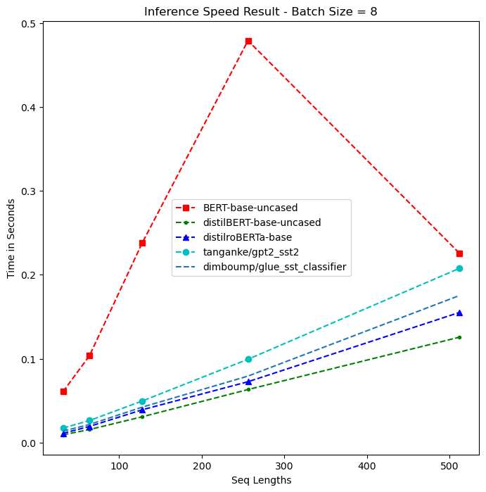

```python
# Plot the results for batch 8
plt.figure(figsize=(8,8))
t = sequence_lengths
plt.xlabel('Seq Lengths')
plt.ylabel('Time in Seconds')
plt.title('Inference Speed Result - Batch Size = 8')
plt.plot(t, models_perf_8[0], 'rs--',
         t, models_perf_8[1], 'g--.',
         t, models_perf_8[2], 'b--^',
         t, models_perf_8[3], 'c--o',
         t, models_perf_8[4], '--'
         )
plt.legend(models)
plt.show()
```

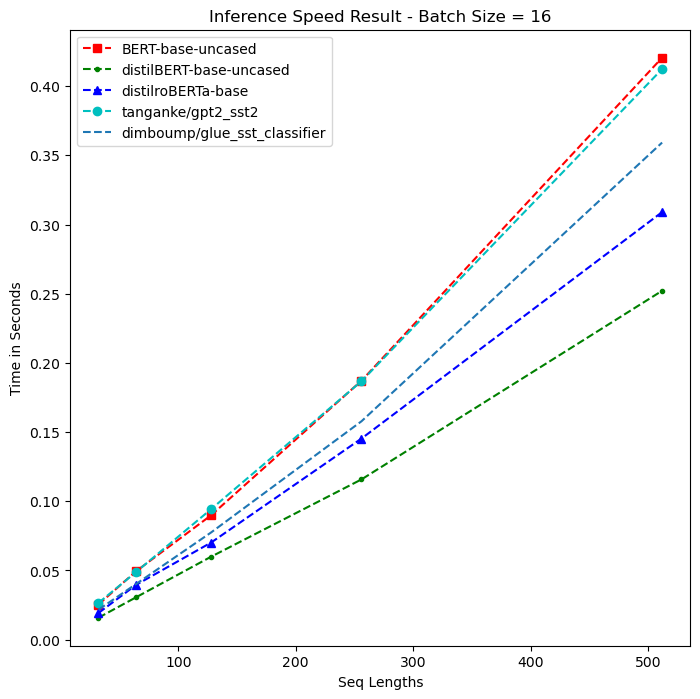

```python
# Plot the results for batch 16
plt.figure(figsize=(8,8))
t = sequence_lengths
plt.xlabel('Seq Lengths')
plt.ylabel('Time in Seconds')
plt.title('Inference Speed Result - Batch Size = 16')
plt.plot(t, models_perf_16[0], 'rs--',
         t, models_perf_16[1], 'g--.',
         t, models_perf_16[2], 'b--^',
         t, models_perf_16[3], 'c--o',
         t, models_perf_16[4], '--'
         )
plt.legend(models)
plt.show()
```

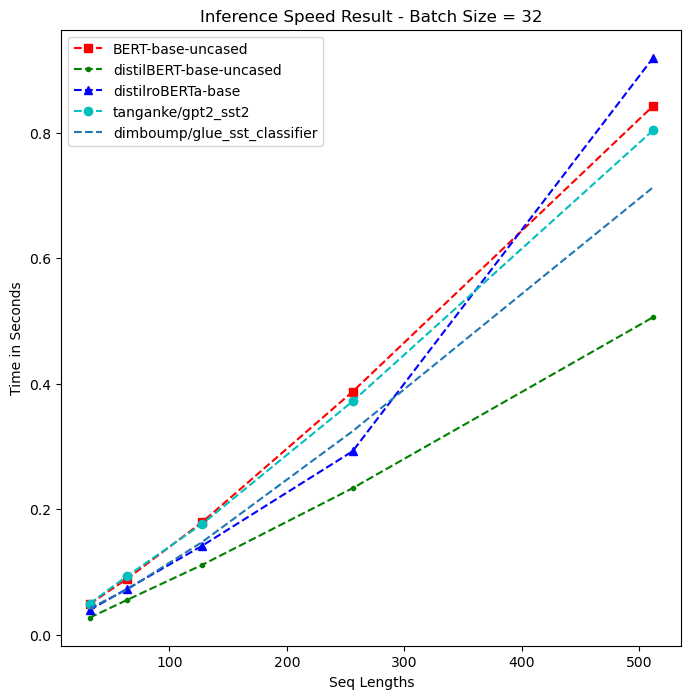

```python
# Plot the results for batch 32
plt.figure(figsize=(8,8))
t = sequence_lengths
plt.xlabel('Seq Lengths')
plt.ylabel('Time in Seconds')
plt.title('Inference Speed Result - Batch Size = 32')
plt.plot(t, models_perf_32[0], 'rs--',
         t, models_perf_32[1], 'g--.',
         t, models_perf_32[2], 'b--^',
         t, models_perf_32[3], 'c--o',
         t, models_perf_32[4], '--'
         )
plt.legend(models)
plt.show()
```

## 4.2 Plotting Inference Memory Results

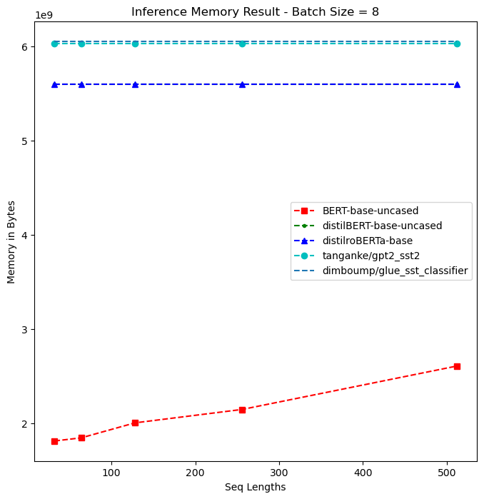

```python
# Plot the results for batch size 8
plt.figure(figsize=(8,8))
t = sequence_lengths
plt.xlabel('Seq Lengths')
plt.ylabel('Memory in Bytes')
plt.title('Inference Memory Result - Batch Size = 8')
plt.plot(t, models_perf_memory_8[0], 'rs--',
         t, models_perf_memory_8[1], 'g--.',
         t, models_perf_memory_8[2], 'b--^',
         t, models_perf_memory_8[3], 'c--o',
         t, models_perf_memory_8[4], '--'
         )
plt.legend(models)
plt.show()
```

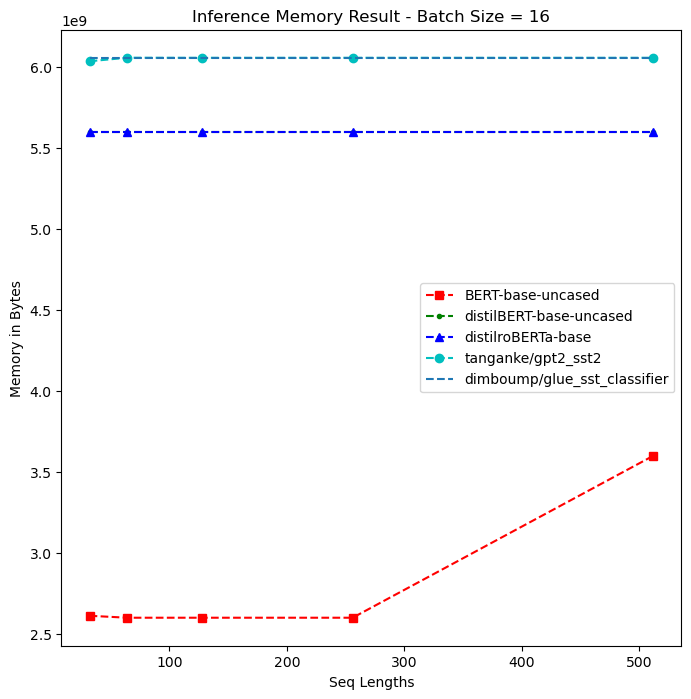

```python
# Plot the results for batch size 16
plt.figure(figsize=(8,8))
t = sequence_lengths
plt.xlabel('Seq Lengths')
plt.ylabel('Memory in Bytes')
plt.title('Inference Memory Result - Batch Size = 16')
plt.plot(t, models_perf_memory_16[0], 'rs--',
         t, models_perf_memory_16[1], 'g--.',
         t, models_perf_memory_16[2], 'b--^',
         t, models_perf_memory_16[3], 'c--o',
         t, models_perf_memory_16[4], '--'
         )
plt.legend(models)
plt.show()
```

[figure not shown]

```python
# Plot the results for batch size 16
plt.figure(figsize=(8,8))
t = sequence_lengths
plt.xlabel('Seq Lengths')
plt.ylabel('Memory in Bytes')
plt.title('Inference Memory Result - Batch Size = 32')
plt.plot(t, models_perf_memory_8[0], 'rs--',
         t, models_perf_memory_8[1], 'g--.',
         t, models_perf_memory_8[2], 'b--^',
         t, models_perf_memory_8[3], 'c--o',
         t, models_perf_memory_8[4], '--'
         )
plt.legend(models)
plt.show()
```

# 5. Function Definitions & Model Deployment

As a case study we user BERT base uncased model first. This model has 12 transformer layers, 768 hidden units per layer, and 12 self attention heads with a total of 110 million parameters

## 5.1 Test and Evaluate the Entire Dataset

The subset cola was chosen because of its relatively small size compared to other subsets, the purpose here is to train a model with the entire dataset and compare that with 5% of the dataset in the next analysis.

```python
# Initilize model names
model_name = "bert-base-uncased"

# Specify dataset and subset, cola is one of the smallest
dataset = "glue"
subset = "cola"

# Load the data set with exception handling
data = load_dataset(dataset, subset)

# Initialize pretrained tokenizer
tokenizer = BertTokenizer.from_pretrained(model_name)

# Load model for sequence classification
model = BertForSequenceClassification.from_pretrained(model_name, num_labels=2)
```

```
Some weights of BertForSequenceClassification were not initialized from the model checkpoint at bert-base-uncased and are newly initialized: ['classifier.bias', 'classifier.weight']
You should probably TRAIN this model on a down-stream task to be able to use it for predictions and inference.
```

```python
# Tokenize the Dataset
def tokenize_function(examples):
    return tokenizer(examples["sentence"], padding="max_length", truncation=True)

tokenized_datasets = data.map(tokenize_function, batched=True)
```

```python
# Make sure sequence lengths match model size limit
data_collator = DataCollatorWithPadding(tokenizer=tokenizer)

# Set up the dataset for training by formatting it to PyTorch tensors and selecting the necessary columns.
tokenized_datasets.set_format("torch", columns=["input_ids", "attention_mask", "label"])
train_dataset = tokenized_datasets["train"]
eval_dataset = tokenized_datasets["validation"]
```

```python
# Fine-Tune the BERT Model using Trainer class

training_args = TrainingArguments(
    output_dir="./results",
    evaluation_strategy="epoch",
    learning_rate=2e-5,
    per_device_train_batch_size=16,
    per_device_eval_batch_size=16,
    num_train_epochs=3,
    weight_decay=0.01,
)

trainer = Trainer(
    model=model,
    args=training_args,
    train_dataset=train_dataset,
    eval_dataset=eval_dataset,
    tokenizer=tokenizer,
    data_collator=data_collator,
)

trainer.train()
```

```
{'loss': 0.4793, 'learning_rate': 1.3769470404984425e-05, 'epoch': 0.93}
```

```
{'eval_loss': 0.4069441556930542, 'eval_runtime': 41.6782, 'eval_samples_per_second': 25.025, 'eval_steps_per_second': 1.584, 'epoch': 1.0}
{'loss': 0.2836, 'learning_rate': 7.538940809968847e-06, 'epoch': 1.87}
```

```
{'eval_loss': 0.4584883451461792, 'eval_runtime': 49.1928, 'eval_samples_per_second': 21.202, 'eval_steps_per_second': 1.342, 'epoch': 2.0}
{'loss': 0.1787, 'learning_rate': 1.308411214953271e-06, 'epoch': 2.8}
```

```
{'eval_loss': 0.5968855619430542, 'eval_runtime': 49.3709, 'eval_samples_per_second': 21.126, 'eval_steps_per_second': 1.337, 'epoch': 3.0}
{'train_runtime': 22751.9058, 'train_samples_per_second': 1.128, 'train_steps_per_second': 0.071, 'train_loss': 0.30500421732014216, 'epoch': 3.0}
```

```
TrainOutput(global_step=1605, training_loss=0.30500421732014216, metrics={'train_runtime': 22751.9058, 'train_samples_per_second': 1.128, 'train_steps_per_second': 0.071, 'train_loss': 0.30500421732014216, 'epoch': 3.0})
```

```python
# Lets evaluate the model performance
trainer.evaluate()
```

```
{'eval_loss': 0.5968855619430542,
 'eval_runtime': 50.4278,
 'eval_samples_per_second': 20.683,
 'eval_steps_per_second': 1.309,
 'epoch': 3.0}
```

```python
# Get predictions on the validation set
predictions_full = trainer.predict(tokenized_datasets["validation"])

# Extract the predicted labels and the true labels
predicted_labels_full = np.argmax(predictions_full.predictions, axis=1)
true_labels_full = predictions_full.label_ids

# Calculate Accuracy
accuracy_full = accuracy_score(true_labels_full, predicted_labels_full)
print(f"Accuracy: {accuracy_full:.4f}")

# Calculate Matthew's Correlation Coefficient (MCC)
mcc_full = matthews_corrcoef(true_labels_full, predicted_labels_full)
print(f"Matthew's Correlation Coefficient: {mcc_full:.4f}")
```

```
Accuracy: 0.8303
Matthew's Correlation Coefficient: 0.5833
```

## 5.2 Test and Evaluate 5% of Dataset

```python
# Load 5% of the dataset to make computation faster
data_5_train = load_dataset(dataset, subset, split='train[:5%]')
data_5_validation = load_dataset(dataset, subset, split='validation[:5%]')
data_5_test = load_dataset(dataset, subset, split='test[:5%]')

# Print results to verify
print(data)
print(data_5_train)
print(data_5_validation)
print(data_5_test)
```

```
DatasetDict({
    train: Dataset({
        features: ['sentence', 'label', 'idx'],
        num_rows: 8551
    })
    validation: Dataset({
        features: ['sentence', 'label', 'idx'],
        num_rows: 1043
    })
    test: Dataset({
        features: ['sentence', 'label', 'idx'],
        num_rows: 1063
    })
})
Dataset({
    features: ['sentence', 'label', 'idx'],
    num_rows: 428
})
Dataset({
    features: ['sentence', 'label', 'idx'],
    num_rows: 52
})
Dataset({
    features: ['sentence', 'label', 'idx'],
    num_rows: 53
})
```

```python
# Tokenize the data
tokenized_5d_train = data_5_train.map(tokenize_function, batched=True)
tokenized_5d_validation = data_5_validation.map(tokenize_function, batched=True)
tokenized_5d_test = data_5_test.map(tokenize_function, batched=True)
```

```python
# Train set format
tokenized_5d_train.set_format("torch", columns=["input_ids", "attention_mask", "label"])
# Validation set format
tokenized_5d_validation.set_format("torch", columns=["input_ids", "attention_mask", "label"])
# Test set format
tokenized_5d_test.set_format("torch", columns=["input_ids", "attention_mask", "label"])
```

```python
# Fine-Tune the BERT Model using Trainer class

trainer_5 = Trainer(
    model=model,
    args=training_args,
    train_dataset=tokenized_5d_train,
    eval_dataset=tokenized_5d_validation,
    tokenizer=tokenizer,
    data_collator=data_collator,
)

trainer_5.train()
```

```
{'eval_loss': 0.8903217911720276, 'eval_runtime': 15.424, 'eval_samples_per_second': 3.371, 'eval_steps_per_second': 0.259, 'epoch': 1.0}
```

```
{'eval_loss': 0.8180277347564697, 'eval_runtime': 15.4748, 'eval_samples_per_second': 3.36, 'eval_steps_per_second': 0.258, 'epoch': 2.0}
```

```
{'eval_loss': 0.9553665518760681, 'eval_runtime': 15.4345, 'eval_samples_per_second': 3.369, 'eval_steps_per_second': 0.259, 'epoch': 3.0}
{'train_runtime': 1299.3361, 'train_samples_per_second': 0.988, 'train_steps_per_second': 0.062, 'train_loss': 0.18022948135564357, 'epoch': 3.0}
```

```
TrainOutput(global_step=81, training_loss=0.18022948135564357, metrics={'train_runtime': 1299.3361, 'train_samples_per_second': 0.988, 'train_steps_per_second': 0.062, 'train_loss': 0.18022948135564357, 'epoch': 3.0})
```

```python
# Lets evaluate the model performance
trainer_5.evaluate()
```

```
{'eval_loss': 0.9553665518760681,
 'eval_runtime': 16.1551,
 'eval_samples_per_second': 3.219,
 'eval_steps_per_second': 0.248,
 'epoch': 3.0}
```

```python
# Get predictions on the validation set
predictions_5 = trainer_5.predict(tokenized_5d_validation)

# Extract the predicted labels and the true labels
predicted_labels_5 = np.argmax(predictions_5.predictions, axis=1)
true_labels_5 = predictions_5.label_ids

# Calculate Accuracy
accuracy_5 = accuracy_score(true_labels_5, predicted_labels_5)
print(f"Accuracy: {accuracy_5:.4f}")

# Calculate Matthew's Correlation Coefficient (MCC)
mcc_5 = matthews_corrcoef(true_labels_5, predicted_labels_5)
print(f"Matthew's Correlation Coefficient: {mcc_5:.4f}")
```

```
Accuracy: 0.7885
Matthew's Correlation Coefficient: 0.4892
```

# 6. Energy Consumption Analysis of Transformers

### Test for GPU

```python
# Check if GPU is available and set the device accordingly
device = pt.device("cuda" if pt.cuda.is_available() else "cpu")

if pt.cuda.is_available():
    # Print the specific GPU device name
    print(f"Using GPU: {pt.cuda.get_device_name(device)}")

    # Print the current device index
    print(f"Current device index: {pt.cuda.current_device()}")

    # Print device properties
    print(f"Device properties: {pt.cuda.get_device_properties(device)}")
else:
    print("CUDA is not available. Running on CPU.")

# Print the device being used
print(f"Device being used: {device}")
```

```
Using GPU: NVIDIA GeForce RTX 3060 Laptop GPU
Current device index: 0
Device properties: _CudaDeviceProperties(name='NVIDIA GeForce RTX 3060 Laptop GPU', major=8, minor=6, total_memory=6143MB, multi_processor_count=30)
Device being used: cuda
```

### Load a Dataset & Model Selection

```python
dataset = 'glue'
subset = 'sst2'

# Load 5% of the dataset to make computation faster
data_5_train = load_dataset(dataset, subset, split='train[:5%]')
data_5_validation = load_dataset(dataset, subset, split='validation[:5%]')
data_5_test = load_dataset(dataset, subset, split='test[:5%]')

# Benchmark a few models
models_test = [
    'BERT-base-uncased',
    'distilBERT-base-uncased',
    'distilroBERTa-base',
    'tanganke/gpt2_sst2',
    'dimboump/glue_sst_classifier'
    ]
```

## 6.1 Stage 1: Energy Consumption Comparison on Various Models during Training & Evaluation

### 6.1.1 Definitions

```python
# Configure the output of the decorator
csv_handler = CSVHandler('result_1.csv')
```

```python
# To compute the desired metrics
def compute_metrics(pred):
    labels = pred.label_ids
    preds = np.argmax(pred.predictions, axis=1)

    acc = accuracy_score(labels, preds)
    mcc = matthews_corrcoef(labels, preds)
    return {'accuracy': acc, 'matthews_correlation': mcc}
```

```python
# Devorator function
@measure_energy(handler=csv_handler, domains=[NvidiaGPUDomain(0)])
def evaluate_model_on_cola(model_name, data_train, data_validation, data_test):

    # Load tokenizer and and model (Pytorch Version)
    tokenizer = AutoTokenizer.from_pretrained(model_name)
    model = AutoModelForSequenceClassification.from_pretrained(model_name)

    # Move the model to the GPU
    model.to(device)

    def tokenize_function(example):
        return tokenizer(example['sentence'], padding="max_length", truncation=True)

    # Tokenize the data
    tokenized_data_train = data_train.map(tokenize_function, batched=True)
    tokenized_data_validation = data_validation.map(tokenize_function, batched=True)
    tokenized_data_test = data_test.map(tokenize_function, batched=True)

    # Set the format for PyTorch and move tensors to the GPU
    tokenized_data_train.set_format("torch", columns=["input_ids", "attention_mask", "label"])
    tokenized_data_validation.set_format("torch", columns=["input_ids", "attention_mask", "label"])
    tokenized_data_test.set_format("torch", columns=["input_ids", "attention_mask", "label"])

    data_collator = DataCollatorWithPadding(tokenizer=tokenizer)

    # Set the training arguments
    training_args = TrainingArguments(
        output_dir="./result_1",
        evaluation_strategy="epoch",
        learning_rate=2e-5,
        # Reduce from 16 to 8 to help with gpu memory error
        per_device_train_batch_size=8,
        per_device_eval_batch_size=8,
        num_train_epochs=3,
        weight_decay=0.01,
        logging_dir='./logs',
        logging_steps=10,
    )

    # Create the trainer for the model
    trainer = Trainer(
        model=model,
        args=training_args,
        train_dataset=tokenized_data_train,
        eval_dataset=tokenized_data_validation,
        tokenizer=tokenizer,
        data_collator=data_collator,
        compute_metrics=compute_metrics,
    )

    trainer.train()
    result = trainer.evaluate()

    return result
```

### 6.1.2 Model Excecution

```python
# To store the results
results = {}
```

```python
# Interate over the list of models
for model_name in models_test:
    print(f"Model to be evaluated: {model_name}")
    result = evaluate_model_on_cola(model_name, data_5_train, data_5_validation, data_5_test)
    results[model_name] = result

# Save the energy consumption results
csv_handler.save_data()
```

```
Model to be evaluated: BERT-base-uncased
```

```
You're using a BertTokenizerFast tokenizer. Please note that with a fast tokenizer, using the `__call__` method is faster than using a method to encode the text followed by a call to the `pad` method to get a padded encoding.
```

[output not shown]

```
{'eval_loss': 0.1883908361196518, 'eval_accuracy': 0.9090909090909091, 'eval_matthews_correlation': 0.8215838362577491, 'eval_runtime': 15.5196, 'eval_samples_per_second': 2.835, 'eval_steps_per_second': 0.387, 'epoch': 1.0}
{'loss': 0.1458, 'learning_rate': 1.3190815518606495e-05, 'epoch': 1.02}
{'loss': 0.2274, 'learning_rate': 1.3032462391132226e-05, 'epoch': 1.05}
{'loss': 0.2743, 'learning_rate': 1.2874109263657959e-05, 'epoch': 1.07}
{'loss': 0.3392, 'learning_rate': 1.271575613618369e-05, 'epoch': 1.09}
{'loss': 0.1162, 'learning_rate': 1.2557403008709424e-05, 'epoch': 1.12}
{'loss': 0.4008, 'learning_rate': 1.2399049881235155e-05, 'epoch': 1.14}
{'loss': 0.197, 'learning_rate': 1.2240696753760888e-05, 'epoch': 1.16}
{'loss': 0.2763, 'learning_rate': 1.208234362628662e-05, 'epoch': 1.19}
{'loss': 0.2152, 'learning_rate': 1.1923990498812352e-05, 'epoch': 1.21}
{'loss': 0.3925, 'learning_rate': 1.1765637371338086e-05, 'epoch': 1.24}
{'loss': 0.2293, 'learning_rate': 1.1607284243863817e-05, 'epoch': 1.26}
{'loss': 0.2331, 'learning_rate': 1.144893111638955e-05, 'epoch': 1.28}
{'loss': 0.1539, 'learning_rate': 1.1290577988915281e-05, 'epoch': 1.31}
{'loss': 0.1602, 'learning_rate': 1.1132224861441014e-05, 'epoch': 1.33}
{'loss': 0.1096, 'learning_rate': 1.0973871733966748e-05, 'epoch': 1.35}
{'loss': 0.1531, 'learning_rate': 1.081551860649248e-05, 'epoch': 1.38}
{'loss': 0.1482, 'learning_rate': 1.0657165479018212e-05, 'epoch': 1.4}
{'loss': 0.2256, 'learning_rate': 1.0498812351543943e-05, 'epoch': 1.43}
{'loss': 0.2398, 'learning_rate': 1.0340459224069676e-05, 'epoch': 1.45}
{'loss': 0.0756, 'learning_rate': 1.0182106096595407e-05, 'epoch': 1.47}
{'loss': 0.1401, 'learning_rate': 1.0023752969121141e-05, 'epoch': 1.5}
{'loss': 0.103, 'learning_rate': 9.865399841646872e-06, 'epoch': 1.52}
{'loss': 0.1265, 'learning_rate': 9.707046714172605e-06, 'epoch': 1.54}
{'loss': 0.1453, 'learning_rate': 9.548693586698338e-06, 'epoch': 1.57}
{'loss': 0.2719, 'learning_rate': 9.39034045922407e-06, 'epoch': 1.59}
{'loss': 0.2602, 'learning_rate': 9.231987331749803e-06, 'epoch': 1.62}
{'loss': 0.1728, 'learning_rate': 9.073634204275536e-06, 'epoch': 1.64}
{'loss': 0.3627, 'learning_rate': 8.915281076801267e-06, 'epoch': 1.66}
{'loss': 0.13, 'learning_rate': 8.756927949327e-06, 'epoch': 1.69}
{'loss': 0.2224, 'learning_rate': 8.598574821852733e-06, 'epoch': 1.71}
{'loss': 0.3613, 'learning_rate': 8.440221694378464e-06, 'epoch': 1.73}
{'loss': 0.1824, 'learning_rate': 8.281868566904197e-06, 'epoch': 1.76}
{'loss': 0.2171, 'learning_rate': 8.12351543942993e-06, 'epoch': 1.78}
{'loss': 0.1868, 'learning_rate': 7.965162311955662e-06, 'epoch': 1.81}
{'loss': 0.2145, 'learning_rate': 7.806809184481395e-06, 'epoch': 1.83}
{'loss': 0.3083, 'learning_rate': 7.648456057007126e-06, 'epoch': 1.85}
{'loss': 0.1623, 'learning_rate': 7.490102929532859e-06, 'epoch': 1.88}
{'loss': 0.098, 'learning_rate': 7.331749802058591e-06, 'epoch': 1.9}
{'loss': 0.262, 'learning_rate': 7.173396674584323e-06, 'epoch': 1.92}
{'loss': 0.099, 'learning_rate': 7.015043547110056e-06, 'epoch': 1.95}
{'loss': 0.0751, 'learning_rate': 6.856690419635789e-06, 'epoch': 1.97}
{'loss': 0.2062, 'learning_rate': 6.698337292161521e-06, 'epoch': 2.0}
```

[output not shown]

```
{'eval_loss': 0.4760882556438446, 'eval_accuracy': 0.9090909090909091, 'eval_matthews_correlation': 0.8215838362577491, 'eval_runtime': 12.7668, 'eval_samples_per_second': 3.446, 'eval_steps_per_second': 0.47, 'epoch': 3.0}
{'train_runtime': 10853.4849, 'train_samples_per_second': 0.931, 'train_steps_per_second': 0.116, 'train_loss': 0.22942002892334926, 'epoch': 3.0}
```

```
Model to be evaluated: distilBERT-base-uncased
```

```
You're using a DistilBertTokenizerFast tokenizer. Please note that with a fast tokenizer, using the `__call__` method is faster than using a method to encode the text followed by a call to the `pad` method to get a padded encoding.
```

[output not shown]

```
{'eval_loss': 0.18021546304225922, 'eval_accuracy': 0.9090909090909091, 'eval_matthews_correlation': 0.8181818181818182, 'eval_runtime': 0.7175, 'eval_samples_per_second': 61.324, 'eval_steps_per_second': 8.362, 'epoch': 1.0}
{'loss': 0.1253, 'learning_rate': 1.3190815518606495e-05, 'epoch': 1.02}
{'loss': 0.2003, 'learning_rate': 1.3032462391132226e-05, 'epoch': 1.05}
{'loss': 0.2679, 'learning_rate': 1.2874109263657959e-05, 'epoch': 1.07}
{'loss': 0.248, 'learning_rate': 1.271575613618369e-05, 'epoch': 1.09}
{'loss': 0.2362, 'learning_rate': 1.2557403008709424e-05, 'epoch': 1.12}
{'loss': 0.2485, 'learning_rate': 1.2399049881235155e-05, 'epoch': 1.14}
{'loss': 0.2686, 'learning_rate': 1.2240696753760888e-05, 'epoch': 1.16}
{'loss': 0.2438, 'learning_rate': 1.208234362628662e-05, 'epoch': 1.19}
{'loss': 0.2283, 'learning_rate': 1.1923990498812352e-05, 'epoch': 1.21}
{'loss': 0.3853, 'learning_rate': 1.1765637371338086e-05, 'epoch': 1.24}
{'loss': 0.2806, 'learning_rate': 1.1607284243863817e-05, 'epoch': 1.26}
{'loss': 0.3732, 'learning_rate': 1.144893111638955e-05, 'epoch': 1.28}
{'loss': 0.1624, 'learning_rate': 1.1290577988915281e-05, 'epoch': 1.31}
{'loss': 0.1394, 'learning_rate': 1.1132224861441014e-05, 'epoch': 1.33}
{'loss': 0.2315, 'learning_rate': 1.0973871733966748e-05, 'epoch': 1.35}
{'loss': 0.1252, 'learning_rate': 1.081551860649248e-05, 'epoch': 1.38}
{'loss': 0.1904, 'learning_rate': 1.0657165479018212e-05, 'epoch': 1.4}
{'loss': 0.3254, 'learning_rate': 1.0498812351543943e-05, 'epoch': 1.43}
{'loss': 0.1247, 'learning_rate': 1.0340459224069676e-05, 'epoch': 1.45}
{'loss': 0.1562, 'learning_rate': 1.0182106096595407e-05, 'epoch': 1.47}
{'loss': 0.1485, 'learning_rate': 1.0023752969121141e-05, 'epoch': 1.5}
{'loss': 0.1878, 'learning_rate': 9.865399841646872e-06, 'epoch': 1.52}
{'loss': 0.1641, 'learning_rate': 9.707046714172605e-06, 'epoch': 1.54}
{'loss': 0.0559, 'learning_rate': 9.548693586698338e-06, 'epoch': 1.57}
{'loss': 0.1936, 'learning_rate': 9.39034045922407e-06, 'epoch': 1.59}
{'loss': 0.1224, 'learning_rate': 9.231987331749803e-06, 'epoch': 1.62}
{'loss': 0.2414, 'learning_rate': 9.073634204275536e-06, 'epoch': 1.64}
{'loss': 0.3182, 'learning_rate': 8.915281076801267e-06, 'epoch': 1.66}
{'loss': 0.266, 'learning_rate': 8.756927949327e-06, 'epoch': 1.69}
{'loss': 0.145, 'learning_rate': 8.598574821852733e-06, 'epoch': 1.71}
{'loss': 0.357, 'learning_rate': 8.440221694378464e-06, 'epoch': 1.73}
{'loss': 0.103, 'learning_rate': 8.281868566904197e-06, 'epoch': 1.76}
{'loss': 0.2259, 'learning_rate': 8.12351543942993e-06, 'epoch': 1.78}
{'loss': 0.1583, 'learning_rate': 7.965162311955662e-06, 'epoch': 1.81}
{'loss': 0.3693, 'learning_rate': 7.806809184481395e-06, 'epoch': 1.83}
{'loss': 0.2737, 'learning_rate': 7.648456057007126e-06, 'epoch': 1.85}
{'loss': 0.1346, 'learning_rate': 7.490102929532859e-06, 'epoch': 1.88}
{'loss': 0.2198, 'learning_rate': 7.331749802058591e-06, 'epoch': 1.9}
{'loss': 0.1277, 'learning_rate': 7.173396674584323e-06, 'epoch': 1.92}
{'loss': 0.2028, 'learning_rate': 7.015043547110056e-06, 'epoch': 1.95}
{'loss': 0.2112, 'learning_rate': 6.856690419635789e-06, 'epoch': 1.97}
{'loss': 0.1414, 'learning_rate': 6.698337292161521e-06, 'epoch': 2.0}
```

[output not shown]

```
{'eval_loss': 0.15116769075393677, 'eval_accuracy': 0.9545454545454546, 'eval_matthews_correlation': 0.9090909090909091, 'eval_runtime': 0.7358, 'eval_samples_per_second': 59.796, 'eval_steps_per_second': 8.154, 'epoch': 3.0}
{'train_runtime': 440.0252, 'train_samples_per_second': 22.956, 'train_steps_per_second': 2.87, 'train_loss': 0.2400189924421805, 'epoch': 3.0}
```

```
Model to be evaluated: distilroBERTa-base
```

```
You're using a RobertaTokenizerFast tokenizer. Please note that with a fast tokenizer, using the `__call__` method is faster than using a method to encode the text followed by a call to the `pad` method to get a padded encoding.
```

[output not shown]

```
{'eval_loss': 0.13602758944034576, 'eval_accuracy': 0.9545454545454546, 'eval_matthews_correlation': 0.9128709291752768, 'eval_runtime': 0.5652, 'eval_samples_per_second': 77.854, 'eval_steps_per_second': 10.616, 'epoch': 1.0}
{'loss': 0.2245, 'learning_rate': 1.3190815518606495e-05, 'epoch': 1.02}
{'loss': 0.2409, 'learning_rate': 1.3032462391132226e-05, 'epoch': 1.05}
{'loss': 0.3065, 'learning_rate': 1.2874109263657959e-05, 'epoch': 1.07}
{'loss': 0.2406, 'learning_rate': 1.271575613618369e-05, 'epoch': 1.09}
{'loss': 0.6288, 'learning_rate': 1.2557403008709424e-05, 'epoch': 1.12}
{'loss': 0.2608, 'learning_rate': 1.2399049881235155e-05, 'epoch': 1.14}
{'loss': 0.2214, 'learning_rate': 1.2240696753760888e-05, 'epoch': 1.16}
{'loss': 0.2588, 'learning_rate': 1.208234362628662e-05, 'epoch': 1.19}
{'loss': 0.3577, 'learning_rate': 1.1923990498812352e-05, 'epoch': 1.21}
{'loss': 0.6144, 'learning_rate': 1.1765637371338086e-05, 'epoch': 1.24}
{'loss': 0.1332, 'learning_rate': 1.1607284243863817e-05, 'epoch': 1.26}
{'loss': 0.3779, 'learning_rate': 1.144893111638955e-05, 'epoch': 1.28}
{'loss': 0.1554, 'learning_rate': 1.1290577988915281e-05, 'epoch': 1.31}
{'loss': 0.2327, 'learning_rate': 1.1132224861441014e-05, 'epoch': 1.33}
{'loss': 0.4339, 'learning_rate': 1.0973871733966748e-05, 'epoch': 1.35}
{'loss': 0.1816, 'learning_rate': 1.081551860649248e-05, 'epoch': 1.38}
{'loss': 0.266, 'learning_rate': 1.0657165479018212e-05, 'epoch': 1.4}
{'loss': 0.2292, 'learning_rate': 1.0498812351543943e-05, 'epoch': 1.43}
{'loss': 0.2753, 'learning_rate': 1.0340459224069676e-05, 'epoch': 1.45}
{'loss': 0.2742, 'learning_rate': 1.0182106096595407e-05, 'epoch': 1.47}
{'loss': 0.4126, 'learning_rate': 1.0023752969121141e-05, 'epoch': 1.5}
{'loss': 0.3176, 'learning_rate': 9.865399841646872e-06, 'epoch': 1.52}
{'loss': 0.3276, 'learning_rate': 9.707046714172605e-06, 'epoch': 1.54}
{'loss': 0.2041, 'learning_rate': 9.548693586698338e-06, 'epoch': 1.57}
{'loss': 0.3071, 'learning_rate': 9.39034045922407e-06, 'epoch': 1.59}
{'loss': 0.2774, 'learning_rate': 9.231987331749803e-06, 'epoch': 1.62}
{'loss': 0.2623, 'learning_rate': 9.073634204275536e-06, 'epoch': 1.64}
{'loss': 0.25, 'learning_rate': 8.915281076801267e-06, 'epoch': 1.66}
{'loss': 0.2261, 'learning_rate': 8.756927949327e-06, 'epoch': 1.69}
{'loss': 0.3648, 'learning_rate': 8.598574821852733e-06, 'epoch': 1.71}
{'loss': 0.2627, 'learning_rate': 8.440221694378464e-06, 'epoch': 1.73}
{'loss': 0.3508, 'learning_rate': 8.281868566904197e-06, 'epoch': 1.76}
{'loss': 0.4542, 'learning_rate': 8.12351543942993e-06, 'epoch': 1.78}
{'loss': 0.2284, 'learning_rate': 7.965162311955662e-06, 'epoch': 1.81}
{'loss': 0.5944, 'learning_rate': 7.806809184481395e-06, 'epoch': 1.83}
{'loss': 0.3952, 'learning_rate': 7.648456057007126e-06, 'epoch': 1.85}
{'loss': 0.3043, 'learning_rate': 7.490102929532859e-06, 'epoch': 1.88}
{'loss': 0.2731, 'learning_rate': 7.331749802058591e-06, 'epoch': 1.9}
{'loss': 0.2418, 'learning_rate': 7.173396674584323e-06, 'epoch': 1.92}
{'loss': 0.1633, 'learning_rate': 7.015043547110056e-06, 'epoch': 1.95}
{'loss': 0.3134, 'learning_rate': 6.856690419635789e-06, 'epoch': 1.97}
{'loss': 0.1799, 'learning_rate': 6.698337292161521e-06, 'epoch': 2.0}
```

[output not shown]

```
{'eval_loss': 0.2153988927602768, 'eval_accuracy': 0.9545454545454546, 'eval_matthews_correlation': 0.9128709291752768, 'eval_runtime': 0.5646, 'eval_samples_per_second': 77.929, 'eval_steps_per_second': 10.627, 'epoch': 3.0}
{'train_runtime': 401.1266, 'train_samples_per_second': 25.182, 'train_steps_per_second': 3.149, 'train_loss': 0.311667311190379, 'epoch': 3.0}
```

```
Model to be evaluated: tanganke/gpt2_sst2
```

```
You're using a GPT2TokenizerFast tokenizer. Please note that with a fast tokenizer, using the `__call__` method is faster than using a method to encode the text followed by a call to the `pad` method to get a padded encoding.
```

```
{'loss': 0.0015, 'learning_rate': 1.9841646872525734e-05, 'epoch': 0.02}
{'loss': 0.2019, 'learning_rate': 1.9683293745051467e-05, 'epoch': 0.05}
{'loss': 0.2312, 'learning_rate': 1.95249406175772e-05, 'epoch': 0.07}
{'loss': 0.2652, 'learning_rate': 1.936658749010293e-05, 'epoch': 0.1}
{'loss': 0.1515, 'learning_rate': 1.9208234362628665e-05, 'epoch': 0.12}
{'loss': 0.1435, 'learning_rate': 1.9049881235154395e-05, 'epoch': 0.14}
{'loss': 0.0682, 'learning_rate': 1.8891528107680128e-05, 'epoch': 0.17}
{'loss': 0.1766, 'learning_rate': 1.873317498020586e-05, 'epoch': 0.19}
{'loss': 0.0087, 'learning_rate': 1.8574821852731593e-05, 'epoch': 0.21}
{'loss': 0.1803, 'learning_rate': 1.8416468725257326e-05, 'epoch': 0.24}
{'loss': 0.0025, 'learning_rate': 1.825811559778306e-05, 'epoch': 0.26}
{'loss': 0.0027, 'learning_rate': 1.809976247030879e-05, 'epoch': 0.29}
{'loss': 0.1466, 'learning_rate': 1.794140934283452e-05, 'epoch': 0.31}
{'loss': 0.0407, 'learning_rate': 1.7783056215360253e-05, 'epoch': 0.33}
{'loss': 0.0695, 'learning_rate': 1.762470308788599e-05, 'epoch': 0.36}
{'loss': 0.1784, 'learning_rate': 1.746634996041172e-05, 'epoch': 0.38}
{'loss': 0.0719, 'learning_rate': 1.730799683293745e-05, 'epoch': 0.4}
{'loss': 0.0022, 'learning_rate': 1.7149643705463184e-05, 'epoch': 0.43}
{'loss': 0.0665, 'learning_rate': 1.6991290577988917e-05, 'epoch': 0.45}
{'loss': 0.122, 'learning_rate': 1.6832937450514647e-05, 'epoch': 0.48}
{'loss': 0.0362, 'learning_rate': 1.6674584323040383e-05, 'epoch': 0.5}
{'loss': 0.0564, 'learning_rate': 1.6516231195566115e-05, 'epoch': 0.52}
{'loss': 0.0357, 'learning_rate': 1.6357878068091845e-05, 'epoch': 0.55}
{'loss': 0.0762, 'learning_rate': 1.6199524940617578e-05, 'epoch': 0.57}
{'loss': 0.0819, 'learning_rate': 1.604117181314331e-05, 'epoch': 0.59}
{'loss': 0.0799, 'learning_rate': 1.5882818685669043e-05, 'epoch': 0.62}
{'loss': 0.0391, 'learning_rate': 1.5724465558194776e-05, 'epoch': 0.64}
{'loss': 0.1874, 'learning_rate': 1.556611243072051e-05, 'epoch': 0.67}
{'loss': 0.0522, 'learning_rate': 1.540775930324624e-05, 'epoch': 0.69}
{'loss': 0.0078, 'learning_rate': 1.5249406175771972e-05, 'epoch': 0.71}
{'loss': 0.2855, 'learning_rate': 1.5091053048297705e-05, 'epoch': 0.74}
{'loss': 0.2354, 'learning_rate': 1.4932699920823436e-05, 'epoch': 0.76}
{'loss': 0.128, 'learning_rate': 1.477434679334917e-05, 'epoch': 0.78}
{'loss': 0.1872, 'learning_rate': 1.4615993665874902e-05, 'epoch': 0.81}
{'loss': 0.1603, 'learning_rate': 1.4457640538400634e-05, 'epoch': 0.83}
{'loss': 0.0152, 'learning_rate': 1.4299287410926367e-05, 'epoch': 0.86}
{'loss': 0.0581, 'learning_rate': 1.4140934283452098e-05, 'epoch': 0.88}
{'loss': 0.0053, 'learning_rate': 1.3982581155977833e-05, 'epoch': 0.9}
{'loss': 0.1389, 'learning_rate': 1.3824228028503564e-05, 'epoch': 0.93}
{'loss': 0.0895, 'learning_rate': 1.3665874901029297e-05, 'epoch': 0.95}
{'loss': 0.1642, 'learning_rate': 1.3507521773555028e-05, 'epoch': 0.97}
{'loss': 0.0416, 'learning_rate': 1.3349168646080762e-05, 'epoch': 1.0}
```

```
{'eval_loss': 0.12478170543909073, 'eval_accuracy': 0.9545454545454546, 'eval_matthews_correlation': 0.9128709291752768, 'eval_runtime': 3.2875, 'eval_samples_per_second': 13.384, 'eval_steps_per_second': 1.825, 'epoch': 1.0}
{'loss': 0.0007, 'learning_rate': 1.3190815518606495e-05, 'epoch': 1.02}
{'loss': 0.0812, 'learning_rate': 1.3032462391132226e-05, 'epoch': 1.05}
{'loss': 0.0628, 'learning_rate': 1.2874109263657959e-05, 'epoch': 1.07}
{'loss': 0.1155, 'learning_rate': 1.271575613618369e-05, 'epoch': 1.09}
{'loss': 0.03, 'learning_rate': 1.2557403008709424e-05, 'epoch': 1.12}
{'loss': 0.1653, 'learning_rate': 1.2399049881235155e-05, 'epoch': 1.14}
{'loss': 0.0904, 'learning_rate': 1.2240696753760888e-05, 'epoch': 1.16}
{'loss': 0.0021, 'learning_rate': 1.208234362628662e-05, 'epoch': 1.19}
{'loss': 0.0797, 'learning_rate': 1.1923990498812352e-05, 'epoch': 1.21}
{'loss': 0.0852, 'learning_rate': 1.1765637371338086e-05, 'epoch': 1.24}
{'loss': 0.0011, 'learning_rate': 1.1607284243863817e-05, 'epoch': 1.26}
{'loss': 0.0437, 'learning_rate': 1.144893111638955e-05, 'epoch': 1.28}
{'loss': 0.0123, 'learning_rate': 1.1290577988915281e-05, 'epoch': 1.31}
{'loss': 0.008, 'learning_rate': 1.1132224861441014e-05, 'epoch': 1.33}
{'loss': 0.0022, 'learning_rate': 1.0973871733966748e-05, 'epoch': 1.35}
{'loss': 0.0007, 'learning_rate': 1.081551860649248e-05, 'epoch': 1.38}
{'loss': 0.0013, 'learning_rate': 1.0657165479018212e-05, 'epoch': 1.4}
{'loss': 0.0954, 'learning_rate': 1.0498812351543943e-05, 'epoch': 1.43}
{'loss': 0.0942, 'learning_rate': 1.0340459224069676e-05, 'epoch': 1.45}
{'loss': 0.0005, 'learning_rate': 1.0182106096595407e-05, 'epoch': 1.47}
{'loss': 0.0006, 'learning_rate': 1.0023752969121141e-05, 'epoch': 1.5}
{'loss': 0.0008, 'learning_rate': 9.865399841646872e-06, 'epoch': 1.52}
{'loss': 0.042, 'learning_rate': 9.707046714172605e-06, 'epoch': 1.54}
{'loss': 0.009, 'learning_rate': 9.548693586698338e-06, 'epoch': 1.57}
{'loss': 0.0238, 'learning_rate': 9.39034045922407e-06, 'epoch': 1.59}
{'loss': 0.0027, 'learning_rate': 9.231987331749803e-06, 'epoch': 1.62}
{'loss': 0.0003, 'learning_rate': 9.073634204275536e-06, 'epoch': 1.64}
{'loss': 0.0012, 'learning_rate': 8.915281076801267e-06, 'epoch': 1.66}
{'loss': 0.0175, 'learning_rate': 8.756927949327e-06, 'epoch': 1.69}
{'loss': 0.088, 'learning_rate': 8.598574821852733e-06, 'epoch': 1.71}
{'loss': 0.001, 'learning_rate': 8.440221694378464e-06, 'epoch': 1.73}
{'loss': 0.0028, 'learning_rate': 8.281868566904197e-06, 'epoch': 1.76}
{'loss': 0.063, 'learning_rate': 8.12351543942993e-06, 'epoch': 1.78}
{'loss': 0.1125, 'learning_rate': 7.965162311955662e-06, 'epoch': 1.81}
{'loss': 0.0958, 'learning_rate': 7.806809184481395e-06, 'epoch': 1.83}
{'loss': 0.0151, 'learning_rate': 7.648456057007126e-06, 'epoch': 1.85}
{'loss': 0.0142, 'learning_rate': 7.490102929532859e-06, 'epoch': 1.88}
{'loss': 0.0391, 'learning_rate': 7.331749802058591e-06, 'epoch': 1.9}
{'loss': 0.0981, 'learning_rate': 7.173396674584323e-06, 'epoch': 1.92}
{'loss': 0.0013, 'learning_rate': 7.015043547110056e-06, 'epoch': 1.95}
{'loss': 0.0683, 'learning_rate': 6.856690419635789e-06, 'epoch': 1.97}
{'loss': 0.0004, 'learning_rate': 6.698337292161521e-06, 'epoch': 2.0}
```

```
{'eval_loss': 0.08118756860494614, 'eval_accuracy': 0.9772727272727273, 'eval_matthews_correlation': 0.9555330859059091, 'eval_runtime': 4.0401, 'eval_samples_per_second': 10.891, 'eval_steps_per_second': 1.485, 'epoch': 2.0}
{'loss': 0.0463, 'learning_rate': 6.539984164687253e-06, 'epoch': 2.02}
{'loss': 0.102, 'learning_rate': 6.3816310372129854e-06, 'epoch': 2.04}
{'loss': 0.0562, 'learning_rate': 6.223277909738717e-06, 'epoch': 2.07}
{'loss': 0.0004, 'learning_rate': 6.06492478226445e-06, 'epoch': 2.09}
{'loss': 0.0151, 'learning_rate': 5.906571654790183e-06, 'epoch': 2.11}
{'loss': 0.0004, 'learning_rate': 5.748218527315916e-06, 'epoch': 2.14}
{'loss': 0.0373, 'learning_rate': 5.5898653998416475e-06, 'epoch': 2.16}
{'loss': 0.0056, 'learning_rate': 5.431512272367379e-06, 'epoch': 2.19}
{'loss': 0.0004, 'learning_rate': 5.273159144893112e-06, 'epoch': 2.21}
{'loss': 0.0099, 'learning_rate': 5.114806017418844e-06, 'epoch': 2.23}
{'loss': 0.0021, 'learning_rate': 4.956452889944577e-06, 'epoch': 2.26}
{'loss': 0.0074, 'learning_rate': 4.798099762470309e-06, 'epoch': 2.28}
{'loss': 0.0003, 'learning_rate': 4.6397466349960415e-06, 'epoch': 2.3}
{'loss': 0.0216, 'learning_rate': 4.481393507521774e-06, 'epoch': 2.33}
{'loss': 0.0987, 'learning_rate': 4.323040380047506e-06, 'epoch': 2.35}
{'loss': 0.0548, 'learning_rate': 4.164687252573238e-06, 'epoch': 2.38}
{'loss': 0.0678, 'learning_rate': 4.006334125098972e-06, 'epoch': 2.4}
{'loss': 0.1085, 'learning_rate': 3.8479809976247036e-06, 'epoch': 2.42}
{'loss': 0.001, 'learning_rate': 3.6896278701504355e-06, 'epoch': 2.45}
{'loss': 0.0003, 'learning_rate': 3.531274742676168e-06, 'epoch': 2.47}
{'loss': 0.0027, 'learning_rate': 3.3729216152019006e-06, 'epoch': 2.49}
{'loss': 0.0005, 'learning_rate': 3.214568487727633e-06, 'epoch': 2.52}
{'loss': 0.0004, 'learning_rate': 3.0562153602533652e-06, 'epoch': 2.54}
{'loss': 0.0004, 'learning_rate': 2.897862232779098e-06, 'epoch': 2.57}
{'loss': 0.0003, 'learning_rate': 2.73950910530483e-06, 'epoch': 2.59}
{'loss': 0.0002, 'learning_rate': 2.581155977830562e-06, 'epoch': 2.61}
{'loss': 0.0002, 'learning_rate': 2.422802850356295e-06, 'epoch': 2.64}
{'loss': 0.0008, 'learning_rate': 2.264449722882027e-06, 'epoch': 2.66}
{'loss': 0.0007, 'learning_rate': 2.1060965954077596e-06, 'epoch': 2.68}
{'loss': 0.0008, 'learning_rate': 1.947743467933492e-06, 'epoch': 2.71}
{'loss': 0.0002, 'learning_rate': 1.789390340459224e-06, 'epoch': 2.73}
{'loss': 0.0019, 'learning_rate': 1.6310372129849566e-06, 'epoch': 2.76}
{'loss': 0.0003, 'learning_rate': 1.472684085510689e-06, 'epoch': 2.78}
{'loss': 0.0002, 'learning_rate': 1.3143309580364213e-06, 'epoch': 2.8}
{'loss': 0.0003, 'learning_rate': 1.1559778305621536e-06, 'epoch': 2.83}
{'loss': 0.0959, 'learning_rate': 9.976247030878861e-07, 'epoch': 2.85}
{'loss': 0.0216, 'learning_rate': 8.392715756136184e-07, 'epoch': 2.87}
{'loss': 0.0759, 'learning_rate': 6.809184481393508e-07, 'epoch': 2.9}
{'loss': 0.0004, 'learning_rate': 5.225653206650831e-07, 'epoch': 2.92}
{'loss': 0.0257, 'learning_rate': 3.642121931908155e-07, 'epoch': 2.95}
{'loss': 0.0001, 'learning_rate': 2.0585906571654793e-07, 'epoch': 2.97}
{'loss': 0.0946, 'learning_rate': 4.750593824228029e-08, 'epoch': 2.99}
```

```
{'eval_loss': 0.1257348209619522, 'eval_accuracy': 0.9772727272727273, 'eval_matthews_correlation': 0.9555330859059091, 'eval_runtime': 3.744, 'eval_samples_per_second': 11.752, 'eval_steps_per_second': 1.603, 'epoch': 3.0}
{'train_runtime': 7202.8791, 'train_samples_per_second': 1.402, 'train_steps_per_second': 0.175, 'train_loss': 0.054821269902377075, 'epoch': 3.0}
```

```
Model to be evaluated: dimboump/glue_sst_classifier
```

```
You're using a BertTokenizerFast tokenizer. Please note that with a fast tokenizer, using the `__call__` method is faster than using a method to encode the text followed by a call to the `pad` method to get a padded encoding.
```

```
{'loss': 0.2466, 'learning_rate': 1.9841646872525734e-05, 'epoch': 0.02}
{'loss': 0.4577, 'learning_rate': 1.9683293745051467e-05, 'epoch': 0.05}
{'loss': 0.2316, 'learning_rate': 1.95249406175772e-05, 'epoch': 0.07}
{'loss': 0.5482, 'learning_rate': 1.936658749010293e-05, 'epoch': 0.1}
{'loss': 0.3112, 'learning_rate': 1.9208234362628665e-05, 'epoch': 0.12}
{'loss': 0.285, 'learning_rate': 1.9049881235154395e-05, 'epoch': 0.14}
{'loss': 0.1595, 'learning_rate': 1.8891528107680128e-05, 'epoch': 0.17}
{'loss': 0.1431, 'learning_rate': 1.873317498020586e-05, 'epoch': 0.19}
{'loss': 0.2307, 'learning_rate': 1.8574821852731593e-05, 'epoch': 0.21}
{'loss': 0.4044, 'learning_rate': 1.8416468725257326e-05, 'epoch': 0.24}
{'loss': 0.0974, 'learning_rate': 1.825811559778306e-05, 'epoch': 0.26}
{'loss': 0.2487, 'learning_rate': 1.809976247030879e-05, 'epoch': 0.29}
{'loss': 0.3907, 'learning_rate': 1.794140934283452e-05, 'epoch': 0.31}
{'loss': 0.2941, 'learning_rate': 1.7783056215360253e-05, 'epoch': 0.33}
{'loss': 0.3692, 'learning_rate': 1.762470308788599e-05, 'epoch': 0.36}
{'loss': 0.3997, 'learning_rate': 1.746634996041172e-05, 'epoch': 0.38}
{'loss': 0.3063, 'learning_rate': 1.730799683293745e-05, 'epoch': 0.4}
{'loss': 0.373, 'learning_rate': 1.7149643705463184e-05, 'epoch': 0.43}
{'loss': 0.3633, 'learning_rate': 1.6991290577988917e-05, 'epoch': 0.45}
{'loss': 0.4486, 'learning_rate': 1.6832937450514647e-05, 'epoch': 0.48}
{'loss': 0.1489, 'learning_rate': 1.6674584323040383e-05, 'epoch': 0.5}
{'loss': 0.2417, 'learning_rate': 1.6516231195566115e-05, 'epoch': 0.52}
{'loss': 0.2626, 'learning_rate': 1.6357878068091845e-05, 'epoch': 0.55}
{'loss': 0.2955, 'learning_rate': 1.6199524940617578e-05, 'epoch': 0.57}
{'loss': 0.0868, 'learning_rate': 1.604117181314331e-05, 'epoch': 0.59}
{'loss': 0.3454, 'learning_rate': 1.5882818685669043e-05, 'epoch': 0.62}
{'loss': 0.4842, 'learning_rate': 1.5724465558194776e-05, 'epoch': 0.64}
{'loss': 0.4313, 'learning_rate': 1.556611243072051e-05, 'epoch': 0.67}
{'loss': 0.3394, 'learning_rate': 1.540775930324624e-05, 'epoch': 0.69}
{'loss': 0.1527, 'learning_rate': 1.5249406175771972e-05, 'epoch': 0.71}
{'loss': 0.2678, 'learning_rate': 1.5091053048297705e-05, 'epoch': 0.74}
{'loss': 0.2249, 'learning_rate': 1.4932699920823436e-05, 'epoch': 0.76}
{'loss': 0.2138, 'learning_rate': 1.477434679334917e-05, 'epoch': 0.78}
{'loss': 0.1837, 'learning_rate': 1.4615993665874902e-05, 'epoch': 0.81}
{'loss': 0.326, 'learning_rate': 1.4457640538400634e-05, 'epoch': 0.83}
{'loss': 0.1861, 'learning_rate': 1.4299287410926367e-05, 'epoch': 0.86}
{'loss': 0.3734, 'learning_rate': 1.4140934283452098e-05, 'epoch': 0.88}
{'loss': 0.2693, 'learning_rate': 1.3982581155977833e-05, 'epoch': 0.9}
{'loss': 0.3746, 'learning_rate': 1.3824228028503564e-05, 'epoch': 0.93}
{'loss': 0.3719, 'learning_rate': 1.3665874901029297e-05, 'epoch': 0.95}
{'loss': 0.4598, 'learning_rate': 1.3507521773555028e-05, 'epoch': 0.97}
{'loss': 0.2531, 'learning_rate': 1.3349168646080762e-05, 'epoch': 1.0}
```

```
{'eval_loss': 0.16080640256404877, 'eval_accuracy': 0.9318181818181818, 'eval_matthews_correlation': 0.8645299348672512, 'eval_runtime': 0.2962, 'eval_samples_per_second': 148.525, 'eval_steps_per_second': 20.253, 'epoch': 1.0}
{'loss': 0.0825, 'learning_rate': 1.3190815518606495e-05, 'epoch': 1.02}
{'loss': 0.1194, 'learning_rate': 1.3032462391132226e-05, 'epoch': 1.05}
{'loss': 0.0122, 'learning_rate': 1.2874109263657959e-05, 'epoch': 1.07}
{'loss': 0.2218, 'learning_rate': 1.271575613618369e-05, 'epoch': 1.09}
{'loss': 0.059, 'learning_rate': 1.2557403008709424e-05, 'epoch': 1.12}
{'loss': 0.2927, 'learning_rate': 1.2399049881235155e-05, 'epoch': 1.14}
{'loss': 0.121, 'learning_rate': 1.2240696753760888e-05, 'epoch': 1.16}
{'loss': 0.0937, 'learning_rate': 1.208234362628662e-05, 'epoch': 1.19}
{'loss': 0.1222, 'learning_rate': 1.1923990498812352e-05, 'epoch': 1.21}
{'loss': 0.1009, 'learning_rate': 1.1765637371338086e-05, 'epoch': 1.24}
{'loss': 0.0055, 'learning_rate': 1.1607284243863817e-05, 'epoch': 1.26}
{'loss': 0.323, 'learning_rate': 1.144893111638955e-05, 'epoch': 1.28}
{'loss': 0.1509, 'learning_rate': 1.1290577988915281e-05, 'epoch': 1.31}
{'loss': 0.0289, 'learning_rate': 1.1132224861441014e-05, 'epoch': 1.33}
{'loss': 0.1099, 'learning_rate': 1.0973871733966748e-05, 'epoch': 1.35}
{'loss': 0.0749, 'learning_rate': 1.081551860649248e-05, 'epoch': 1.38}
{'loss': 0.2183, 'learning_rate': 1.0657165479018212e-05, 'epoch': 1.4}
{'loss': 0.1475, 'learning_rate': 1.0498812351543943e-05, 'epoch': 1.43}
{'loss': 0.0679, 'learning_rate': 1.0340459224069676e-05, 'epoch': 1.45}
{'loss': 0.0112, 'learning_rate': 1.0182106096595407e-05, 'epoch': 1.47}
{'loss': 0.0401, 'learning_rate': 1.0023752969121141e-05, 'epoch': 1.5}
{'loss': 0.1026, 'learning_rate': 9.865399841646872e-06, 'epoch': 1.52}
{'loss': 0.1712, 'learning_rate': 9.707046714172605e-06, 'epoch': 1.54}
{'loss': 0.0905, 'learning_rate': 9.548693586698338e-06, 'epoch': 1.57}
{'loss': 0.0528, 'learning_rate': 9.39034045922407e-06, 'epoch': 1.59}
{'loss': 0.2399, 'learning_rate': 9.231987331749803e-06, 'epoch': 1.62}
{'loss': 0.105, 'learning_rate': 9.073634204275536e-06, 'epoch': 1.64}
{'loss': 0.1185, 'learning_rate': 8.915281076801267e-06, 'epoch': 1.66}
{'loss': 0.2603, 'learning_rate': 8.756927949327e-06, 'epoch': 1.69}
{'loss': 0.076, 'learning_rate': 8.598574821852733e-06, 'epoch': 1.71}
{'loss': 0.0917, 'learning_rate': 8.440221694378464e-06, 'epoch': 1.73}
{'loss': 0.065, 'learning_rate': 8.281868566904197e-06, 'epoch': 1.76}
{'loss': 0.2664, 'learning_rate': 8.12351543942993e-06, 'epoch': 1.78}
{'loss': 0.1137, 'learning_rate': 7.965162311955662e-06, 'epoch': 1.81}
{'loss': 0.114, 'learning_rate': 7.806809184481395e-06, 'epoch': 1.83}
{'loss': 0.2271, 'learning_rate': 7.648456057007126e-06, 'epoch': 1.85}
{'loss': 0.1016, 'learning_rate': 7.490102929532859e-06, 'epoch': 1.88}
{'loss': 0.1334, 'learning_rate': 7.331749802058591e-06, 'epoch': 1.9}
{'loss': 0.3127, 'learning_rate': 7.173396674584323e-06, 'epoch': 1.92}
{'loss': 0.1134, 'learning_rate': 7.015043547110056e-06, 'epoch': 1.95}
{'loss': 0.1091, 'learning_rate': 6.856690419635789e-06, 'epoch': 1.97}
{'loss': 0.0903, 'learning_rate': 6.698337292161521e-06, 'epoch': 2.0}
```

```
{'eval_loss': 0.3489530384540558, 'eval_accuracy': 0.9090909090909091, 'eval_matthews_correlation': 0.8215838362577491, 'eval_runtime': 0.3143, 'eval_samples_per_second': 140.008, 'eval_steps_per_second': 19.092, 'epoch': 2.0}
{'loss': 0.1474, 'learning_rate': 6.539984164687253e-06, 'epoch': 2.02}
{'loss': 0.032, 'learning_rate': 6.3816310372129854e-06, 'epoch': 2.04}
{'loss': 0.0542, 'learning_rate': 6.223277909738717e-06, 'epoch': 2.07}
{'loss': 0.0339, 'learning_rate': 6.06492478226445e-06, 'epoch': 2.09}
{'loss': 0.0018, 'learning_rate': 5.906571654790183e-06, 'epoch': 2.11}
{'loss': 0.0021, 'learning_rate': 5.748218527315916e-06, 'epoch': 2.14}
{'loss': 0.0017, 'learning_rate': 5.5898653998416475e-06, 'epoch': 2.16}
{'loss': 0.001, 'learning_rate': 5.431512272367379e-06, 'epoch': 2.19}
{'loss': 0.0323, 'learning_rate': 5.273159144893112e-06, 'epoch': 2.21}
{'loss': 0.1578, 'learning_rate': 5.114806017418844e-06, 'epoch': 2.23}
{'loss': 0.001, 'learning_rate': 4.956452889944577e-06, 'epoch': 2.26}
{'loss': 0.0007, 'learning_rate': 4.798099762470309e-06, 'epoch': 2.28}
{'loss': 0.1425, 'learning_rate': 4.6397466349960415e-06, 'epoch': 2.3}
{'loss': 0.0008, 'learning_rate': 4.481393507521774e-06, 'epoch': 2.33}
{'loss': 0.0229, 'learning_rate': 4.323040380047506e-06, 'epoch': 2.35}
{'loss': 0.171, 'learning_rate': 4.164687252573238e-06, 'epoch': 2.38}
{'loss': 0.1789, 'learning_rate': 4.006334125098972e-06, 'epoch': 2.4}
{'loss': 0.2392, 'learning_rate': 3.8479809976247036e-06, 'epoch': 2.42}
{'loss': 0.0716, 'learning_rate': 3.6896278701504355e-06, 'epoch': 2.45}
{'loss': 0.1012, 'learning_rate': 3.531274742676168e-06, 'epoch': 2.47}
{'loss': 0.0052, 'learning_rate': 3.3729216152019006e-06, 'epoch': 2.49}
{'loss': 0.0011, 'learning_rate': 3.214568487727633e-06, 'epoch': 2.52}
{'loss': 0.0008, 'learning_rate': 3.0562153602533652e-06, 'epoch': 2.54}
{'loss': 0.0798, 'learning_rate': 2.897862232779098e-06, 'epoch': 2.57}
{'loss': 0.1747, 'learning_rate': 2.73950910530483e-06, 'epoch': 2.59}
{'loss': 0.0009, 'learning_rate': 2.581155977830562e-06, 'epoch': 2.61}
{'loss': 0.0006, 'learning_rate': 2.422802850356295e-06, 'epoch': 2.64}
{'loss': 0.1066, 'learning_rate': 2.264449722882027e-06, 'epoch': 2.66}
{'loss': 0.0101, 'learning_rate': 2.1060965954077596e-06, 'epoch': 2.68}
{'loss': 0.0014, 'learning_rate': 1.947743467933492e-06, 'epoch': 2.71}
{'loss': 0.0006, 'learning_rate': 1.789390340459224e-06, 'epoch': 2.73}
{'loss': 0.0067, 'learning_rate': 1.6310372129849566e-06, 'epoch': 2.76}
{'loss': 0.001, 'learning_rate': 1.472684085510689e-06, 'epoch': 2.78}
{'loss': 0.0006, 'learning_rate': 1.3143309580364213e-06, 'epoch': 2.8}
{'loss': 0.077, 'learning_rate': 1.1559778305621536e-06, 'epoch': 2.83}
{'loss': 0.0009, 'learning_rate': 9.976247030878861e-07, 'epoch': 2.85}
{'loss': 0.0005, 'learning_rate': 8.392715756136184e-07, 'epoch': 2.87}
{'loss': 0.0824, 'learning_rate': 6.809184481393508e-07, 'epoch': 2.9}
{'loss': 0.0008, 'learning_rate': 5.225653206650831e-07, 'epoch': 2.92}
{'loss': 0.0727, 'learning_rate': 3.642121931908155e-07, 'epoch': 2.95}
{'loss': 0.1738, 'learning_rate': 2.0585906571654793e-07, 'epoch': 2.97}
{'loss': 0.0027, 'learning_rate': 4.750593824228029e-08, 'epoch': 2.99}
```

```
{'eval_loss': 0.3264878988265991, 'eval_accuracy': 0.9318181818181818, 'eval_matthews_correlation': 0.8645299348672512, 'eval_runtime': 0.3067, 'eval_samples_per_second': 143.452, 'eval_steps_per_second': 19.562, 'epoch': 3.0}
{'train_runtime': 219.7435, 'train_samples_per_second': 45.967, 'train_steps_per_second': 5.748, 'train_loss': 0.159584943149814, 'epoch': 3.0}
```

### 6.1.3 Plot the Results

```python
# Lets extract the data and clean it into a pandas dataframe
e_results = pd.read_csv('result_1.csv')

e_results = e_results.iloc[:,0].str.split(";", expand=True)

e_results.columns = ['timestamp', 'function', 'duration', 'gpu energy consumption (joules)']

pprint(e_results)
```

```
            timestamp                function            duration  \
0   1724296877.357065  evaluate_model_on_cola  10869.785194635391
1  1724307747.1462488  evaluate_model_on_cola  443.26426935195923
2  1724308190.4115155  evaluate_model_on_cola  404.21812200546265
3  1724308594.6316319  evaluate_model_on_cola   7209.450871229172
4  1724315804.0835006  evaluate_model_on_cola    222.703022480011

  gpu energy consumption (joules)
0                       670421569
1                        33202009
2                        32289034
3                       460350643
4                        17157219
```

```python
# Print out the results
for model_name, result in results.items():
    print(f"Results for {model_name}: {result}")
```

```
Results for BERT-base-uncased: {'eval_loss': 0.4760882556438446, 'eval_accuracy': 0.9090909090909091, 'eval_matthews_correlation': 0.8215838362577491, 'eval_runtime': 12.5873, 'eval_samples_per_second': 3.496, 'eval_steps_per_second': 0.477, 'epoch': 3.0}
Results for distilBERT-base-uncased: {'eval_loss': 0.15116769075393677, 'eval_accuracy': 0.9545454545454546, 'eval_matthews_correlation': 0.9090909090909091, 'eval_runtime': 0.7135, 'eval_samples_per_second': 61.667, 'eval_steps_per_second': 8.409, 'epoch': 3.0}
Results for distilroBERTa-base: {'eval_loss': 0.2153988927602768, 'eval_accuracy': 0.9545454545454546, 'eval_matthews_correlation': 0.9128709291752768, 'eval_runtime': 0.5543, 'eval_samples_per_second': 79.378, 'eval_steps_per_second': 10.824, 'epoch': 3.0}
Results for tanganke/gpt2_sst2: {'eval_loss': 0.1257348209619522, 'eval_accuracy': 0.9772727272727273, 'eval_matthews_correlation': 0.9555330859059091, 'eval_runtime': 3.3535, 'eval_samples_per_second': 13.121, 'eval_steps_per_second': 1.789, 'epoch': 3.0}
Results for dimboump/glue_sst_classifier: {'eval_loss': 0.3264878988265991, 'eval_accuracy': 0.9318181818181818, 'eval_matthews_correlation': 0.8645299348672512, 'eval_runtime': 0.2885, 'eval_samples_per_second': 152.514, 'eval_steps_per_second': 20.797, 'epoch': 3.0}
```

```python
# Convert the results to a DataFrame
results_df = pd.DataFrame(results).T

results_df.reset_index(inplace=True)

results_df.columns = ['Model', 'Loss', 'Accuracy', 'Matthews Correlation', 'Runtime (s)', 'Samples per Second', 'Steps per Second', 'Epoch']

print(results_df)
```

```
                          Model      Loss  Accuracy  Matthews Correlation  \
0             BERT-base-uncased  0.476088  0.909091              0.821584
1       distilBERT-base-uncased  0.151168  0.954545              0.909091
2            distilroBERTa-base  0.215399  0.954545              0.912871
3            tanganke/gpt2_sst2  0.125735  0.977273              0.955533
4  dimboump/glue_sst_classifier  0.326488  0.931818              0.864530

   Runtime (s)  Samples per Second  Steps per Second  Epoch
0      12.5873               3.496             0.477    3.0
1       0.7135              61.667             8.409    3.0
2       0.5543              79.378            10.824    3.0
3       3.3535              13.121             1.789    3.0
4       0.2885             152.514            20.797    3.0
```

```python
# Merge final file from both results
merged_results = pd.concat([results_df, e_results], axis=1)

merged_results['gpu energy consumption (joules)'] = merged_results['gpu energy consumption (joules)'].astype(float)
merged_results['duration'] = merged_results['duration'].astype(float)

print(merged_results)
```

```
                          Model      Loss  Accuracy  Matthews Correlation  \
0             BERT-base-uncased  0.476088  0.909091              0.821584
1       distilBERT-base-uncased  0.151168  0.954545              0.909091
2            distilroBERTa-base  0.215399  0.954545              0.912871
3            tanganke/gpt2_sst2  0.125735  0.977273              0.955533
4  dimboump/glue_sst_classifier  0.326488  0.931818              0.864530

   Runtime (s)  Samples per Second  Steps per Second  Epoch  \
0      12.5873               3.496             0.477    3.0
1       0.7135              61.667             8.409    3.0
2       0.5543              79.378            10.824    3.0
3       3.3535              13.121             1.789    3.0
4       0.2885             152.514            20.797    3.0

            timestamp                function      duration  \
0   1724296877.357065  evaluate_model_on_cola  10869.785195
1  1724307747.1462488  evaluate_model_on_cola    443.264269
2  1724308190.4115155  evaluate_model_on_cola    404.218122
3  1724308594.6316319  evaluate_model_on_cola   7209.450871
4  1724315804.0835006  evaluate_model_on_cola    222.703022

   gpu energy consumption (joules)
0                      670421569.0
1                       33202009.0
2                       32289034.0
3                      460350643.0
4                       17157219.0
```

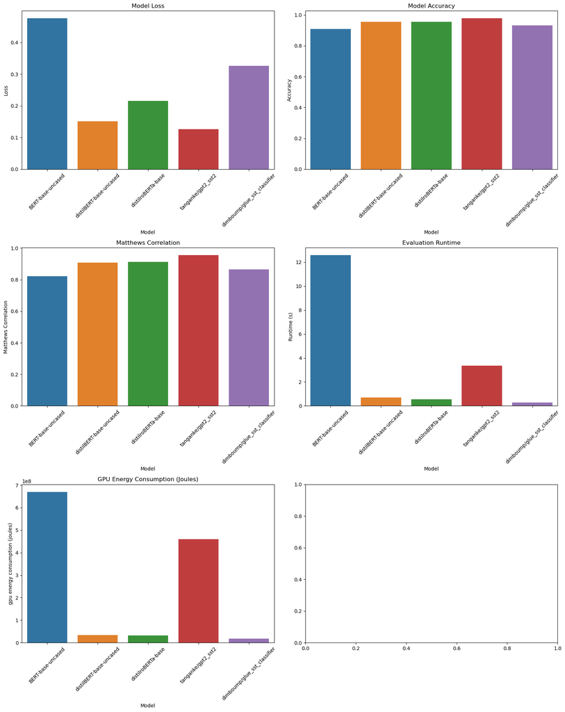

```python
# Set up the figure and axis
fig, ax = plt.subplots(3, 2, figsize=(16, 20))

# Plot Loss
sns.barplot(x='Model', y='Loss', data=merged_results, ax=ax[0, 0])
ax[0, 0].set_title('Model Loss')
ax[0, 0].tick_params(axis='x', rotation=45)

# Plot Accuracy
sns.barplot(x='Model', y='Accuracy', data=merged_results, ax=ax[0, 1])
ax[0, 1].set_title('Model Accuracy')
ax[0, 1].tick_params(axis='x', rotation=45)

# Plot Matthews Correlation
sns.barplot(x='Model', y='Matthews Correlation', data=merged_results, ax=ax[1, 0])
ax[1, 0].set_title('Matthews Correlation')
ax[1, 0].tick_params(axis='x', rotation=45)

# Plot Runtime
sns.barplot(x='Model', y='Runtime (s)', data=merged_results, ax=ax[1, 1])
ax[1, 1].set_title('Evaluation Runtime')
ax[1, 1].tick_params(axis='x', rotation=45)

# Plot Runtime
sns.barplot(x='Model', y='gpu energy consumption (joules)', data=merged_results, ax=ax[2, 0])
ax[2, 0].set_title('GPU Energy Consumption (Joules)')
ax[2, 0].tick_params(axis='x', rotation=45)

# Adjust layout
plt.tight_layout()
plt.show()
```

## 6.2 Stage 2: Energy Consumption Comparison on Various Models per Query

### 6.2.1 Load the Dataset

```python
dataset = 'glue'
# Sentiment Analysis
subset = 'sst2'

# Load 5% of the dataset to make computation faster
data_query_train = load_dataset(dataset, subset, split='train[:2%]')
data_query_validation = load_dataset(dataset, subset, split='validation[:673]')
data_query_test = load_dataset(dataset, subset, split='test[:1%]')
```

```python
print(data_query_train)
print(data_query_validation)
print(data_query_test)
```

```
Dataset({
    features: ['sentence', 'label', 'idx'],
    num_rows: 1347
})
Dataset({
    features: ['sentence', 'label', 'idx'],
    num_rows: 673
})
Dataset({
    features: ['sentence', 'label', 'idx'],
    num_rows: 18
})
```

### 6.2.2 Plot the sentence lengths as a distribution

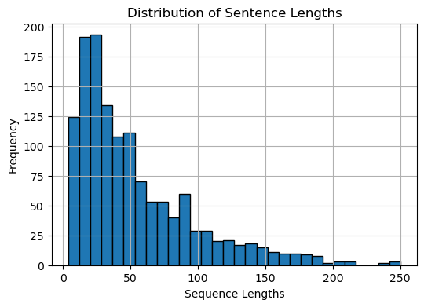

```python
# Convert to dataframe
data_query_train_df = pd.DataFrame(data_query_train)

# Create a dataframe with the length of each sentence
data_query_train_df["sentence length"] = data_query_train_df['sentence'].apply(len)

# Plot the lengths
plt.figure(figsize=(6,4))
plt.hist(data_query_train_df["sentence length"], bins=30, edgecolor='black')
plt.title("Distribution of Sentence Lengths")
plt.xlabel('Sequence Lengths')
plt.ylabel('Frequency')
plt.grid(True)
plt.show()
```

### 6.2.3 Plot the token lengths as a distribution

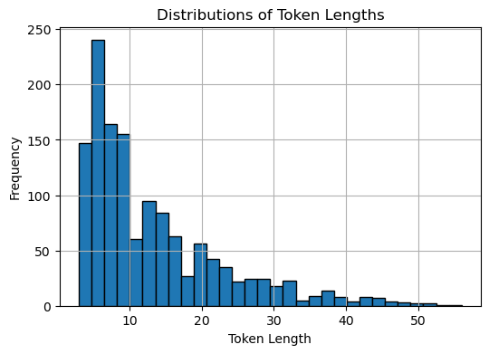

```python
# Rnadomly choose one of the models
model_token_test = 'bert-base-uncased'

# Load the tokenizer and model
tokenizer_perce_test = AutoTokenizer.from_pretrained(model_token_test)
model_perce_query = AutoModelForSequenceClassification.from_pretrained(model_token_test)

# Function to tokenize the data
def tokenize_function(example):
    return tokenizer_perce_test(example['sentence'], padding="max_length", truncation=True)

# Function to calculate token length
def get_token_length(sentence):
    tokens = tokenizer_perce_test(sentence, truncation=True, padding=True)
    return len(tokens['input_ids'])

# Convert DataFrame to dictionary
def df_to_dict(df):
    return df.to_dict(orient='list')

# Add token length column to the DataFrame
data_query_train_df["token length"] = data_query_train_df["sentence"].apply(get_token_length)

#  Plot the results
plt.figure(figsize=(6,4))
plt.hist(data_query_train_df["token length"], bins = 30, edgecolor="black")
plt.title("Distributions of Token Lengths")
plt.xlabel("Token Length")
plt.ylabel("Frequency")
plt.grid(True)
plt.show()
```

### 6.2.4 Training each Query

```python
# Initialize CSV file
csv_handler_2 = CSVHandler('results_2.csv')

@measure_energy(handler=csv_handler_2, domains=[NvidiaGPUDomain(0)])
def evaluate_model_query(model_query, query_train, data_collator_query):
    training_args_query = TrainingArguments(
        output_dir='./results',
        num_train_epochs=1,  # Only 1 epoch since it's just for energy measurement
        per_device_train_batch_size=1,  # Single batch size for single query training
        logging_dir='./logs',
        logging_steps=10,
    )

    trainer_query = Trainer(
        model=model_query,
        args=training_args_query,
        train_dataset=query_train,
        data_collator=data_collator_query,
    )

    # Only perform training
    trainer_query.train()
```

```python
models_test = [
    'BERT-base-uncased',
    'distilBERT-base-uncased',
    'distilroBERTa-base',
    'tanganke/gpt2_sst2',
    'dimboump/glue_sst_classifier'
    ]

predictions = []
```

```python
# Loop through each model and each subset for evaluation
for model_name in models_test:
    # Load the tokenizer and model
    tokenizer_query = AutoTokenizer.from_pretrained(model_name)
    model_query = AutoModelForSequenceClassification.from_pretrained(model_name)

    # Move the model to the GPU
    model_query.to(device)

    # Tokenize the entire dataset
    tokenized_train_query = data_query_train.map(lambda x: tokenizer_query(x['sentence'], truncation=True, padding=True, max_length=512), batched=True)
    tokenized_train_query.set_format("torch", columns=["input_ids", "attention_mask", "label"])

    data_collator_query = DataCollatorWithPadding(tokenizer=tokenizer_query)

    # Store the results
    for i in range(len(tokenized_train_query)):
        # Optionally print debug information
        query_train = tokenized_train_query.select([i])

        # Evaluate the model on the current subset
        evaluate_model_query(model_query, query_train, data_collator_query)

# Save the predictions to a CSV file
csv_handler_2.save_data()
```

```
You're using a BertTokenizerFast tokenizer. Please note that with a fast tokenizer, using the `__call__` method is faster than using a method to encode the text followed by a call to the `pad` method to get a padded encoding.
```

```
{'train_runtime': 0.1731, 'train_samples_per_second': 5.778, 'train_steps_per_second': 5.778, 'train_loss': 0.2916227877140045, 'epoch': 1.0}
```

```
{'train_runtime': 0.173, 'train_samples_per_second': 5.78, 'train_steps_per_second': 5.78, 'train_loss': 0.1779043972492218, 'epoch': 1.0}
```

```
{'train_runtime': 0.1558, 'train_samples_per_second': 6.42, 'train_steps_per_second': 6.42, 'train_loss': 1.9980974197387695, 'epoch': 1.0}
```

```
{'train_runtime': 0.1574, 'train_samples_per_second': 6.354, 'train_steps_per_second': 6.354, 'train_loss': 0.33060768246650696, 'epoch': 1.0}
```

```
{'train_runtime': 0.1435, 'train_samples_per_second': 6.967, 'train_steps_per_second': 6.967, 'train_loss': 0.17681139707565308, 'epoch': 1.0}
```

```
{'train_runtime': 0.1443, 'train_samples_per_second': 6.929, 'train_steps_per_second': 6.929, 'train_loss': 0.16437368094921112, 'epoch': 1.0}
```

```
{'train_runtime': 0.1458, 'train_samples_per_second': 6.856, 'train_steps_per_second': 6.856, 'train_loss': 2.3128015995025635, 'epoch': 1.0}
```

```
{'train_runtime': 0.1641, 'train_samples_per_second': 6.094, 'train_steps_per_second': 6.094, 'train_loss': 1.9895497560501099, 'epoch': 1.0}
```

```
{'train_runtime': 0.148, 'train_samples_per_second': 6.758, 'train_steps_per_second': 6.758, 'train_loss': 0.40539756417274475, 'epoch': 1.0}
```

```
{'train_runtime': 0.145, 'train_samples_per_second': 6.896, 'train_steps_per_second': 6.896, 'train_loss': 1.8709056377410889, 'epoch': 1.0}
```

```
{'train_runtime': 0.1455, 'train_samples_per_second': 6.871, 'train_steps_per_second': 6.871, 'train_loss': 0.3639920949935913, 'epoch': 1.0}
```

```
{'train_runtime': 0.1502, 'train_samples_per_second': 6.657, 'train_steps_per_second': 6.657, 'train_loss': 0.1545075923204422, 'epoch': 1.0}
```

```
{'train_runtime': 0.14, 'train_samples_per_second': 7.142, 'train_steps_per_second': 7.142, 'train_loss': 0.10488623380661011, 'epoch': 1.0}
```

```
{'train_runtime': 0.1482, 'train_samples_per_second': 6.748, 'train_steps_per_second': 6.748, 'train_loss': 0.08516053855419159, 'epoch': 1.0}
```

```
{'train_runtime': 0.1462, 'train_samples_per_second': 6.84, 'train_steps_per_second': 6.84, 'train_loss': 0.06093098595738411, 'epoch': 1.0}
```

```
{'train_runtime': 0.1484, 'train_samples_per_second': 6.738, 'train_steps_per_second': 6.738, 'train_loss': 3.0193517208099365, 'epoch': 1.0}
```

```
{'train_runtime': 0.1412, 'train_samples_per_second': 7.083, 'train_steps_per_second': 7.083, 'train_loss': 0.17915286123752594, 'epoch': 1.0}
```

```
{'train_runtime': 0.1384, 'train_samples_per_second': 7.225, 'train_steps_per_second': 7.225, 'train_loss': 2.8506383895874023, 'epoch': 1.0}
```

```
{'train_runtime': 0.148, 'train_samples_per_second': 6.758, 'train_steps_per_second': 6.758, 'train_loss': 0.09048719704151154, 'epoch': 1.0}
```

```
{'train_runtime': 0.1479, 'train_samples_per_second': 6.762, 'train_steps_per_second': 6.762, 'train_loss': 2.852081060409546, 'epoch': 1.0}
```

```
{'train_runtime': 0.1359, 'train_samples_per_second': 7.356, 'train_steps_per_second': 7.356, 'train_loss': 1.0691652297973633, 'epoch': 1.0}
```

```
{'train_runtime': 0.1454, 'train_samples_per_second': 6.876, 'train_steps_per_second': 6.876, 'train_loss': 0.29973551630973816, 'epoch': 1.0}
```

```
{'train_runtime': 0.144, 'train_samples_per_second': 6.944, 'train_steps_per_second': 6.944, 'train_loss': 0.10600408911705017, 'epoch': 1.0}
```

```
{'train_runtime': 0.1611, 'train_samples_per_second': 6.208, 'train_steps_per_second': 6.208, 'train_loss': 0.06541649997234344, 'epoch': 1.0}
```

```
{'train_runtime': 0.1535, 'train_samples_per_second': 6.514, 'train_steps_per_second': 6.514, 'train_loss': 0.49960365891456604, 'epoch': 1.0}
```

```
{'train_runtime': 0.1357, 'train_samples_per_second': 7.37, 'train_steps_per_second': 7.37, 'train_loss': 2.2633731365203857, 'epoch': 1.0}
```

```
{'train_runtime': 0.1516, 'train_samples_per_second': 6.595, 'train_steps_per_second': 6.595, 'train_loss': 0.1588287055492401, 'epoch': 1.0}
```

```
{'train_runtime': 0.1541, 'train_samples_per_second': 6.489, 'train_steps_per_second': 6.489, 'train_loss': 2.5413153171539307, 'epoch': 1.0}
```

```
{'train_runtime': 0.1449, 'train_samples_per_second': 6.903, 'train_steps_per_second': 6.903, 'train_loss': 1.8993923664093018, 'epoch': 1.0}
```

```
{'train_runtime': 0.1449, 'train_samples_per_second': 6.902, 'train_steps_per_second': 6.902, 'train_loss': 0.26751381158828735, 'epoch': 1.0}
```

```
{'train_runtime': 0.1482, 'train_samples_per_second': 6.747, 'train_steps_per_second': 6.747, 'train_loss': 0.12643159925937653, 'epoch': 1.0}
```

```
{'train_runtime': 0.1461, 'train_samples_per_second': 6.843, 'train_steps_per_second': 6.843, 'train_loss': 2.2190515995025635, 'epoch': 1.0}
```

```
{'train_runtime': 0.1512, 'train_samples_per_second': 6.615, 'train_steps_per_second': 6.615, 'train_loss': 0.15017768740653992, 'epoch': 1.0}
```

```
{'train_runtime': 0.1427, 'train_samples_per_second': 7.009, 'train_steps_per_second': 7.009, 'train_loss': 1.1920928244535389e-07, 'epoch': 1.0}
```

```
{'train_runtime': 0.1879, 'train_samples_per_second': 5.322, 'train_steps_per_second': 5.322, 'train_loss': 0.0, 'epoch': 1.0}
```

```
{'train_runtime': 0.1787, 'train_samples_per_second': 5.597, 'train_steps_per_second': 5.597, 'train_loss': 0.0, 'epoch': 1.0}
```

```
{'train_runtime': 0.1829, 'train_samples_per_second': 5.467, 'train_steps_per_second': 5.467, 'train_loss': 0.0, 'epoch': 1.0}
```

```
{'train_runtime': 0.1461, 'train_samples_per_second': 6.843, 'train_steps_per_second': 6.843, 'train_loss': 9.737584114074707, 'epoch': 1.0}
```

```
{'train_runtime': 0.1496, 'train_samples_per_second': 6.686, 'train_steps_per_second': 6.686, 'train_loss': 2.905243396759033, 'epoch': 1.0}
```

```
{'train_runtime': 0.1612, 'train_samples_per_second': 6.203, 'train_steps_per_second': 6.203, 'train_loss': 0.0, 'epoch': 1.0}
```

```
{'train_runtime': 0.1368, 'train_samples_per_second': 7.309, 'train_steps_per_second': 7.309, 'train_loss': 4.768370445162873e-07, 'epoch': 1.0}
```

```
{'train_runtime': 0.1495, 'train_samples_per_second': 6.688, 'train_steps_per_second': 6.688, 'train_loss': 1.4185804502631072e-05, 'epoch': 1.0}
```

```
{'train_runtime': 0.1826, 'train_samples_per_second': 5.475, 'train_steps_per_second': 5.475, 'train_loss': 0.0, 'epoch': 1.0}
```

```
{'train_runtime': 0.184, 'train_samples_per_second': 5.434, 'train_steps_per_second': 5.434, 'train_loss': 0.0, 'epoch': 1.0}
```

```
{'train_runtime': 0.1956, 'train_samples_per_second': 5.114, 'train_steps_per_second': 5.114, 'train_loss': 16.829620361328125, 'epoch': 1.0}
```

```
{'train_runtime': 0.1851, 'train_samples_per_second': 5.402, 'train_steps_per_second': 5.402, 'train_loss': 1.1920928244535389e-07, 'epoch': 1.0}
```

```
{'train_runtime': 0.1768, 'train_samples_per_second': 5.658, 'train_steps_per_second': 5.658, 'train_loss': 8.344646857949556e-07, 'epoch': 1.0}
```

```
{'train_runtime': 0.1838, 'train_samples_per_second': 5.442, 'train_steps_per_second': 5.442, 'train_loss': 0.0, 'epoch': 1.0}
```

```
{'train_runtime': 0.1524, 'train_samples_per_second': 6.561, 'train_steps_per_second': 6.561, 'train_loss': 0.0, 'epoch': 1.0}
```

```
{'train_runtime': 0.139, 'train_samples_per_second': 7.194, 'train_steps_per_second': 7.194, 'train_loss': 0.0, 'epoch': 1.0}
```

```
{'train_runtime': 0.152, 'train_samples_per_second': 6.58, 'train_steps_per_second': 6.58, 'train_loss': 7.152555099310121e-07, 'epoch': 1.0}
```

```
{'train_runtime': 0.17, 'train_samples_per_second': 5.882, 'train_steps_per_second': 5.882, 'train_loss': 0.0, 'epoch': 1.0}
```

```
{'train_runtime': 0.1606, 'train_samples_per_second': 6.227, 'train_steps_per_second': 6.227, 'train_loss': 0.0, 'epoch': 1.0}
```

```
{'train_runtime': 0.1659, 'train_samples_per_second': 6.027, 'train_steps_per_second': 6.027, 'train_loss': 0.0, 'epoch': 1.0}
```

```
{'train_runtime': 0.1908, 'train_samples_per_second': 5.24, 'train_steps_per_second': 5.24, 'train_loss': 0.0, 'epoch': 1.0}
```

```
{'train_runtime': 0.147, 'train_samples_per_second': 6.802, 'train_steps_per_second': 6.802, 'train_loss': 13.633790016174316, 'epoch': 1.0}
```

```
{'train_runtime': 0.1444, 'train_samples_per_second': 6.924, 'train_steps_per_second': 6.924, 'train_loss': 1.1920928244535389e-07, 'epoch': 1.0}
```

```
{'train_runtime': 0.1566, 'train_samples_per_second': 6.386, 'train_steps_per_second': 6.386, 'train_loss': 0.0, 'epoch': 1.0}
```

```
{'train_runtime': 0.1347, 'train_samples_per_second': 7.426, 'train_steps_per_second': 7.426, 'train_loss': 16.397708892822266, 'epoch': 1.0}
```

```
{'train_runtime': 0.1594, 'train_samples_per_second': 6.274, 'train_steps_per_second': 6.274, 'train_loss': 0.0, 'epoch': 1.0}
```

```
{'train_runtime': 0.1875, 'train_samples_per_second': 5.333, 'train_steps_per_second': 5.333, 'train_loss': 0.0, 'epoch': 1.0}
```

```
{'train_runtime': 0.1838, 'train_samples_per_second': 5.44, 'train_steps_per_second': 5.44, 'train_loss': 15.491537094116211, 'epoch': 1.0}
```

### 6.2.5 Plot the Results

```python
results_2_pd = pd.read_csv('results_2.csv')

results_2_pd = results_2_pd['timestamp;tag;duration;nvidia_gpu_0'].str.split(';', expand=True)

results_2_pd = results_2_pd.drop(results_2_pd.columns[[0, 1]], axis=1)

results_2_pd.rename(columns={2: 'Duration', 3:'Energy (Joules)'}, inplace=True)

sequence_length = data_query_train_df["sentence length"]
# Stack the DataFrame on top of itself 5 times
query_energy_results = pd.concat([sequence_length] * 5, ignore_index=True)

results_2_pd['Sequence Length'] = query_energy_results

results_2_pd['Model'] = [model for model in models_test for _ in range(len(data_query_train_df["sentence length"]))]

# Convert the first three columns to float
results_2_pd.iloc[:, :3] = results_2_pd.iloc[:, :3].astype(float)

results_2_pd.to_csv('Results - Model E-Consumption per Query.csv')
```

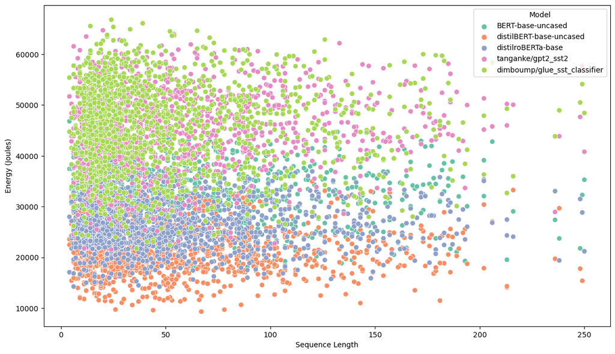

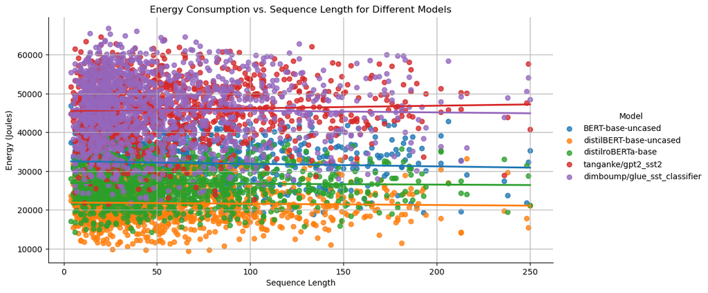

```python
# Set up the plotting environment
plt.figure(figsize=(14, 8))

# Create a scatter plot with hue based on the model
sns.scatterplot(data=results_2_pd, x='Sequence Length', y='Energy (Joules)', hue='Model', palette='Set2', s=50)

# Add a regression line to see the trend for each model
sns.lmplot(data=results_2_pd, x='Sequence Length', y='Energy (Joules)', hue='Model', ci=None, markers="o", aspect=2)

# Customize the plot
plt.title('Energy Consumption vs. Sequence Length for Different Models')
plt.xlabel('Sequence Length')
plt.ylabel('Energy (Joules)')
plt.grid(True)
plt.show()
```

Plot binned results

```
   Sequence Length  Sequence Length Percentile Bin
0             44.0                               2
1             36.0                               1
2             89.0                               3
3             56.0                               2
4             73.0                               2
                           Model  Sequence Length Percentile Bin  \
0              BERT-base-uncased                               0
1              BERT-base-uncased                               1
2              BERT-base-uncased                               2
3              BERT-base-uncased                               3
4   dimboump/glue_sst_classifier                               0
5   dimboump/glue_sst_classifier                               1
6   dimboump/glue_sst_classifier                               2
7   dimboump/glue_sst_classifier                               3
```

[output cut: 34 more lines]

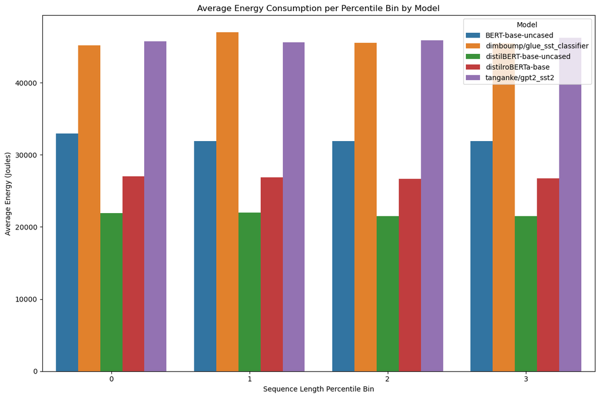

```python
# Define the number of bins (e.g., 4 for quartiles, 10 for deciles)
num_bins = 4

# Bin the sequence lengths by percentile
results_2_pd['Sequence Length Percentile Bin'] = pd.qcut(results_2_pd['Sequence Length'], q=num_bins, labels=False)
print(results_2_pd[['Sequence Length', 'Sequence Length Percentile Bin']].head())

# Group by Model and Sequence Length Percentile Bin, then calculate the mean energy consumption
grouped_data = results_2_pd.groupby(['Model', 'Sequence Length Percentile Bin'])['Energy (Joules)'].mean().reset_index()

# Display the grouped data to verify
print(grouped_data)

# Set the size of the plot
plt.figure(figsize=(12, 8))

# Create a barplot to compare energy consumption across models and percentile bins
sns.barplot(x='Sequence Length Percentile Bin', y='Energy (Joules)', hue='Model', data=grouped_data)

# Set the title and labels
plt.title('Average Energy Consumption per Percentile Bin by Model')
plt.xlabel('Sequence Length Percentile Bin')
plt.ylabel('Average Energy (Joules)')

# Show the plot
plt.tight_layout()
plt.show()
```

Concludion from this section: Energy consumption is unaffected by query length. At least not enough time to run the entire dataset but the results seem to be clear. Other options to look at:

- Model size: Compare energy consumption across different model sizes (e.g., BERT-base vs. BERT-large).
- Hardware differences: Look into how different hardware setups (GPUs, TPUs, CPUs) affect energy consumption.
- Batch size: Evaluate whether processing inputs in larger batches has any impact.
- Inference time vs. energy trade-offs: Consider whether certain models trade off between speed and energy efficiency.

## 6.4 Stage 3: Energy Consumption over Different Satges of The Transformer Pipeline (Future Work)

## 6.5 Stage 4: Energy Efficiency of Various Tunned Models (Future Work)

Quantization, Pruning, Vocabulary Transfer, and Distillation

## 6.3 Energy Consumption over Query Complexity (Future Work)